None

# Исследование объявлений о продаже квартир

## Введение

В нашем распоряжении данные сервиса Яндекс.Недвижимость — архив объявлений о продаже квартир в Санкт-Петербурге и соседних населённых пунктов за несколько лет.

**Цели**:

- Нужно научиться определять рыночную стоимость объектов недвижимости.
- Установить параметры. Рассмотреть влияние параметров друг на друга, а так же определим их наиболее вероятные значения при работе на рынке недвижимости.

По каждой квартире на продажу доступны два вида данных. Первые вписаны пользователем, вторые — получены автоматически на основе картографических данных. Например, расстояние до центра, аэропорта, ближайшего парка и водоёма.

**Описание данных**

- `airports_nearest` — расстояние до ближайшего аэропорта в метрах (м)
- `balcony` — число балконов
- `ceiling_height` — высота потолков (м)
- `cityCenters_nearest` — расстояние до центра города (м) (`city_centers_nearest`)
- `days_exposition` — сколько дней было размещено объявление (от публикации до снятия)
- `first_day_exposition` — дата публикации
- `floor` — этаж
- `floors_total` — всего этажей в доме
- `is_apartment` — апартаменты (булев тип)
- `kitchen_area` — площадь кухни в квадратных метрах (м²)
- `last_price` — цена на момент снятия с публикации
- `living_area` — жилая площадь в квадратных метрах (м²)
- `locality_name` — название населённого пункта
- `open_plan` — свободная планировка (булев тип)
- `parks_around3000` — число парков в радиусе 3 км
- `parks_nearest` — расстояние до ближайшего парка (м)
- `ponds_around3000` — число водоёмов в радиусе 3 км
- `ponds_nearest` — расстояние до ближайшего водоёма (м)
- `rooms` — число комнат
- `studio` — квартира-студия (булев тип)
- `total_area` — общая площадь квартиры в квадратных метрах (м²)
- `total_images` — число фотографий квартиры в объявлении
- `parks_around3000` - количество парков в радиусе 3000 метров
- `ponds_around3000` - количество водоёмов в радиусе 3000 метров

## Откройте файл с данными и изучите общую информацию.

### Загрузим нужные библиотеки

```python
import pandas as pd
import matplotlib.pyplot as plt
import numpy as np
import warnings

warnings.filterwarnings("ignore")
```

### Откроем файл

```python
# версия для ревьюера
data = pd.read_csv('https://code.s3.yandex.net/datasets/real_estate_data.csv', sep='\t')
# Локальная версия
# data = pd.read_csv('real_estate_data.csv', sep='\t', decimal='.')
data.head()
```

|  | total_images | last_price | total_area | first_day_exposition | rooms | ceiling_height | floors_total | living_area | floor | is_apartment | ... | kitchen_area | balcony | locality_name | airports_nearest | cityCenters_nearest | parks_around3000 | parks_nearest | ponds_around3000 | ponds_nearest | days_exposition |
| --- | --- | --- | --- | --- | --- | --- | --- | --- | --- | --- | --- | --- | --- | --- | --- | --- | --- | --- | --- | --- | --- |
| 0 | 20 | 13000000.0 | 108.0 | 2019-03-07T00:00:00 | 3 | 2.70 | 16.0 | 51.0 | 8 | NaN | ... | 25.0 | NaN | Санкт-Петербург | 18863.0 | 16028.0 | 1.0 | 482.0 | 2.0 | 755.0 | NaN |
| 1 | 7 | 3350000.0 | 40.4 | 2018-12-04T00:00:00 | 1 | NaN | 11.0 | 18.6 | 1 | NaN | ... | 11.0 | 2.0 | посёлок Шушары | 12817.0 | 18603.0 | 0.0 | NaN | 0.0 | NaN | 81.0 |
| 2 | 10 | 5196000.0 | 56.0 | 2015-08-20T00:00:00 | 2 | NaN | 5.0 | 34.3 | 4 | NaN | ... | 8.3 | 0.0 | Санкт-Петербург | 21741.0 | 13933.0 | 1.0 | 90.0 | 2.0 | 574.0 | 558.0 |
| 3 | 0 | 64900000.0 | 159.0 | 2015-07-24T00:00:00 | 3 | NaN | 14.0 | NaN | 9 | NaN | ... | NaN | 0.0 | Санкт-Петербург | 28098.0 | 6800.0 | 2.0 | 84.0 | 3.0 | 234.0 | 424.0 |
| 4 | 2 | 10000000.0 | 100.0 | 2018-06-19T00:00:00 | 2 | 3.03 | 14.0 | 32.0 | 13 | NaN | ... | 41.0 | NaN | Санкт-Петербург | 31856.0 | 8098.0 | 2.0 | 112.0 | 1.0 | 48.0 | 121.0 |

5 rows × 22 columns

Обратим внимание, что в нашем файле разделителями являются *"\t"*, а десятичным разделителем *"."*.

### Изучим общую информацию

#### Информация о данных.

```python
data.info()
```

```
<class 'pandas.core.frame.DataFrame'>
RangeIndex: 23699 entries, 0 to 23698
Data columns (total 22 columns):
 #   Column                Non-Null Count  Dtype
---  ------                --------------  -----
 0   total_images          23699 non-null  int64
 1   last_price            23699 non-null  float64
 2   total_area            23699 non-null  float64
 3   first_day_exposition  23699 non-null  object
 4   rooms                 23699 non-null  int64
 5   ceiling_height        14504 non-null  float64
 6   floors_total          23613 non-null  float64
 7   living_area           21796 non-null  float64
 8   floor                 23699 non-null  int64
 9   is_apartment          2775 non-null   object
 10  studio                23699 non-null  bool
 11  open_plan             23699 non-null  bool
 12  kitchen_area          21421 non-null  float64
 13  balcony               12180 non-null  float64
 14  locality_name         23650 non-null  object
 15  airports_nearest      18157 non-null  float64
 16  cityCenters_nearest   18180 non-null  float64
 17  parks_around3000      18181 non-null  float64
 18  parks_nearest         8079 non-null   float64
 19  ponds_around3000      18181 non-null  float64
 20  ponds_nearest         9110 non-null   float64
 21  days_exposition       20518 non-null  float64
dtypes: bool(2), float64(14), int64(3), object(3)
memory usage: 3.7+ MB
```

Отметим, что названия столбцов сделаны хорошо и только один столбец требует переименования.

Данные содержат более 23 тысяч записей, что достаточно для проведения анализа.

```python
data = data.rename(columns={'cityCenters_nearest': 'city_centers_nearest'})
data.info()
```

```
<class 'pandas.core.frame.DataFrame'>
RangeIndex: 23699 entries, 0 to 23698
Data columns (total 22 columns):
 #   Column                Non-Null Count  Dtype
---  ------                --------------  -----
 0   total_images          23699 non-null  int64
 1   last_price            23699 non-null  float64
 2   total_area            23699 non-null  float64
 3   first_day_exposition  23699 non-null  object
 4   rooms                 23699 non-null  int64
 5   ceiling_height        14504 non-null  float64
 6   floors_total          23613 non-null  float64
 7   living_area           21796 non-null  float64
 8   floor                 23699 non-null  int64
 9   is_apartment          2775 non-null   object
 10  studio                23699 non-null  bool
 11  open_plan             23699 non-null  bool
 12  kitchen_area          21421 non-null  float64
 13  balcony               12180 non-null  float64
 14  locality_name         23650 non-null  object
 15  airports_nearest      18157 non-null  float64
 16  city_centers_nearest  18180 non-null  float64
 17  parks_around3000      18181 non-null  float64
 18  parks_nearest         8079 non-null   float64
 19  ponds_around3000      18181 non-null  float64
 20  ponds_nearest         9110 non-null   float64
 21  days_exposition       20518 non-null  float64
dtypes: bool(2), float64(14), int64(3), object(3)
memory usage: 3.7+ MB
```

#### Зависимость столбцов друг от друга

```python
data.corr()
```

|  | total_images | last_price | total_area | rooms | ceiling_height | floors_total | living_area | floor | studio | open_plan | kitchen_area | balcony | airports_nearest | city_centers_nearest | parks_around3000 | parks_nearest | ponds_around3000 | ponds_nearest | days_exposition |
| --- | --- | --- | --- | --- | --- | --- | --- | --- | --- | --- | --- | --- | --- | --- | --- | --- | --- | --- | --- |
| total_images | 1.000000 | 0.104473 | 0.115352 | 0.099288 | -0.001987 | 0.010427 | 0.104780 | 0.031340 | -0.029303 | -0.024407 | 0.104756 | 0.121693 | -0.002298 | -0.047666 | 0.021120 | -0.008347 | -0.011553 | -0.003034 | -0.026657 |
| last_price | 0.104473 | 1.000000 | 0.653675 | 0.363343 | 0.085430 | -0.006984 | 0.566492 | 0.026576 | -0.025362 | -0.008802 | 0.519869 | 0.029646 | -0.026239 | -0.206747 | 0.151058 | -0.016414 | 0.159996 | -0.084809 | 0.081146 |
| total_area | 0.115352 | 0.653675 | 1.000000 | 0.758344 | 0.095490 | -0.075774 | 0.939537 | -0.024754 | -0.072653 | -0.034885 | 0.609121 | 0.047937 | -0.030753 | -0.231446 | 0.164689 | -0.021497 | 0.162346 | -0.097969 | 0.149675 |
| rooms | 0.099288 | 0.363343 | 0.758344 | 1.000000 | 0.054457 | -0.228215 | 0.845977 | -0.150862 | -0.147286 | -0.087500 | 0.269945 | 0.017991 | -0.061199 | -0.184864 | 0.137257 | -0.054549 | 0.092693 | -0.057689 | 0.126961 |
| ceiling_height | -0.001987 | 0.085430 | 0.095490 | 0.054457 | 1.000000 | -0.028732 | 0.090650 | -0.011798 | 0.001674 | 0.042777 | 0.087641 | 0.040523 | -0.023947 | -0.091689 | 0.065915 | -0.019167 | 0.078209 | -0.059090 | 0.019091 |
| floors_total | 0.010427 | -0.006984 | -0.075774 | -0.228215 | -0.028732 | 1.000000 | -0.169311 | 0.678059 | 0.070151 | 0.050791 | 0.163944 | 0.194065 | 0.108288 | 0.019774 | -0.252833 | 0.097527 | -0.122735 | 0.038864 | -0.052234 |
| living_area | 0.104780 | 0.566492 | 0.939537 | 0.845977 | 0.090650 | -0.169311 | 1.000000 | -0.097210 | -0.056231 | -0.033711 | 0.428674 | 0.018849 | -0.057912 | -0.231368 | 0.184453 | -0.050167 | 0.148933 | -0.081674 | 0.142454 |
| floor | 0.031340 | 0.026576 | -0.024754 | -0.150862 | -0.011798 | 0.678059 | -0.097210 | 1.000000 | 0.036940 | 0.035824 | 0.135531 | 0.168773 | 0.071597 | 0.009084 | -0.163784 | 0.073045 | -0.076312 | 0.024850 | -0.039463 |
| studio | -0.029303 | -0.025362 | -0.072653 | -0.147286 | 0.001674 | 0.070151 | -0.056231 | 0.036940 | 1.000000 | -0.004235 | NaN | 0.031455 | -0.021876 | -0.007029 | -0.030202 | 0.009134 | 0.000939 | 0.002606 | -0.022476 |
| open_plan | -0.024407 | -0.008802 | -0.034885 | -0.087500 | 0.042777 | 0.050791 | -0.033711 | 0.035824 | -0.004235 | 1.000000 | NaN | 0.019491 | -0.013583 | -0.004204 | -0.010077 | 0.010612 | 0.008455 | -0.003328 | -0.024112 |
| kitchen_area | 0.104756 | 0.519869 | 0.609121 | 0.269945 | 0.087641 | 0.163944 | 0.428674 | 0.135531 | NaN | NaN | 1.000000 | 0.098634 | 0.008200 | -0.190049 | 0.087503 | 0.029641 | 0.150148 | -0.105223 | 0.100586 |
| balcony | 0.121693 | 0.029646 | 0.047937 | 0.017991 | 0.040523 | 0.194065 | 0.018849 | 0.168773 | 0.031455 | 0.019491 | 0.098634 | 1.000000 | 0.066834 | 0.051051 | -0.082850 | 0.052328 | -0.032709 | 0.010847 | -0.032909 |
| airports_nearest | -0.002298 | -0.026239 | -0.030753 | -0.061199 | -0.023947 | 0.108288 | -0.057912 | 0.071597 | -0.021876 | -0.013583 | 0.008200 | 0.066834 | 1.000000 | 0.272184 | 0.000759 | -0.070058 | -0.049583 | 0.014049 | -0.018271 |
| city_centers_nearest | -0.047666 | -0.206747 | -0.231446 | -0.184864 | -0.091689 | 0.019774 | -0.231368 | 0.009084 | -0.007029 | -0.004204 | -0.190049 | 0.051051 | 0.272184 | 1.000000 | -0.161738 | -0.040650 | -0.074577 | 0.028903 | -0.060714 |
| parks_around3000 | 0.021120 | 0.151058 | 0.164689 | 0.137257 | 0.065915 | -0.252833 | 0.184453 | -0.163784 | -0.030202 | -0.010077 | 0.087503 | -0.082850 | 0.000759 | -0.161738 | 1.000000 | -0.259514 | 0.304316 | -0.167103 | 0.060491 |
| parks_nearest | -0.008347 | -0.016414 | -0.021497 | -0.054549 | -0.019167 | 0.097527 | -0.050167 | 0.073045 | 0.009134 | 0.010612 | 0.029641 | 0.052328 | -0.070058 | -0.040650 | -0.259514 | 1.000000 | 0.077280 | 0.000692 | 0.023254 |
| ponds_around3000 | -0.011553 | 0.159996 | 0.162346 | 0.092693 | 0.078209 | -0.122735 | 0.148933 | -0.076312 | 0.000939 | 0.008455 | 0.150148 | -0.032709 | -0.049583 | -0.074577 | 0.304316 | 0.077280 | 1.000000 | -0.341840 | 0.073162 |
| ponds_nearest | -0.003034 | -0.084809 | -0.097969 | -0.057689 | -0.059090 | 0.038864 | -0.081674 | 0.024850 | 0.002606 | -0.003328 | -0.105223 | 0.010847 | 0.014049 | 0.028903 | -0.167103 | 0.000692 | -0.341840 | 1.000000 | -0.077879 |
| days_exposition | -0.026657 | 0.081146 | 0.149675 | 0.126961 | 0.019091 | -0.052234 | 0.142454 | -0.039463 | -0.022476 | -0.024112 | 0.100586 | -0.032909 | -0.018271 | -0.060714 | 0.060491 | 0.023254 | 0.073162 | -0.077879 | 1.000000 |

#### Поиск дубликатов

Проверим данные на явные дубликаты.

```python
display(f'Количество дубликатов {data.duplicated().sum()}')
```

```
'Количество дубликатов 0'
```

```python
display(f'Процент будликатов от общего числа данных {data.duplicated().sum() / len(data):.0%}')
```

```
'Процент будликатов от общего числа данных 0%'
```

#### Немного визуализируем данные.

```
array([[<AxesSubplot:title={'center':'total_images'}>,
        <AxesSubplot:title={'center':'last_price'}>,
        <AxesSubplot:title={'center':'total_area'}>,
        <AxesSubplot:title={'center':'rooms'}>],
       [<AxesSubplot:title={'center':'ceiling_height'}>,
        <AxesSubplot:title={'center':'floors_total'}>,
        <AxesSubplot:title={'center':'living_area'}>,
        <AxesSubplot:title={'center':'floor'}>],
       [<AxesSubplot:title={'center':'kitchen_area'}>,
        <AxesSubplot:title={'center':'balcony'}>,
        <AxesSubplot:title={'center':'airports_nearest'}>,
        <AxesSubplot:title={'center':'city_centers_nearest'}>],
       [<AxesSubplot:title={'center':'parks_around3000'}>,
        <AxesSubplot:title={'center':'parks_nearest'}>,
        <AxesSubplot:title={'center':'ponds_around3000'}>,
        <AxesSubplot:title={'center':'ponds_nearest'}>],
       [<AxesSubplot:title={'center':'days_exposition'}>, <AxesSubplot:>,
        <AxesSubplot:>, <AxesSubplot:>]], dtype=object)
```

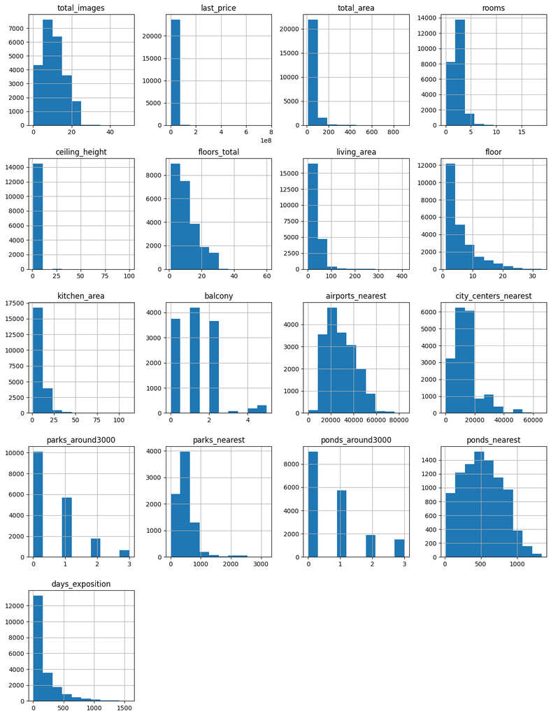

```python
data.hist(figsize=(15, 20))
```

На первый взгляд данные имеют хорошее качество. Скорее всего в базе представлено много недвижимости близкой к стандартной, но есть и эксклюзивные объекты. Проверим данные более подробно.

## Предобработка данных

### Пропущенные значения

Найдем сколько пропущенных данных в каждом из столбцов.

```python
data.isna().sum()
```

```
total_images                0
last_price                  0
total_area                  0
first_day_exposition        0
rooms                       0
ceiling_height           9195
floors_total               86
living_area              1903
floor                       0
is_apartment            20924
studio                      0
open_plan                   0
kitchen_area             2278
balcony                 11519
locality_name              49
airports_nearest         5542
city_centers_nearest     5519
parks_around3000         5518
parks_nearest           15620
ponds_around3000         5518
ponds_nearest           14589
days_exposition          3181
dtype: int64
```

При заполнении пропусков мы частично проверим данные на достоверность, чтобы лучше понимать, чем мы можем заполнить пропуски, и, возможно, немного исправим не достоверные данные.

#### Заполнение пропусков

##### `ceiling_height` — высота потолков (м)

```python
nan_ceiling_height = data['ceiling_height'].isna().sum() / len(data)
display(f'Процент пропусков от общего числа данных {nan_ceiling_height:.0%}')
```

```
'Процент пропусков от общего числа данных 39%'
```

```python
data['ceiling_height'].value_counts().head(20)
```

```
2.50    3515
2.60    1646
2.70    1574
3.00    1112
2.80     993
2.55     980
2.75     910
2.65     676
3.20     277
3.10     203
2.90     164
3.30     141
2.56     139
3.50     130
2.57     103
2.85     101
3.40      92
2.54      83
2.64      81
2.52      79
Name: ceiling_height, dtype: int64
```

```python
data['ceiling_height'].describe()
```

```
count    14504.000000
mean         2.771499
std          1.261056
min          1.000000
25%          2.520000
50%          2.650000
75%          2.800000
max        100.000000
Name: ceiling_height, dtype: float64
```

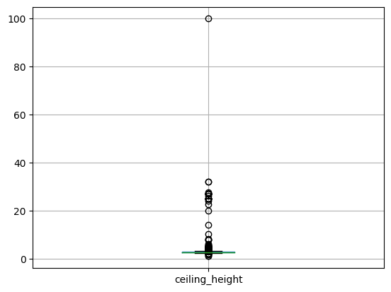

```python
data.boxplot(column='ceiling_height')
plt.show()
```

Как мы видим в столбце `ceiling_height` — высота потолков (м) хранится 183 уникальных значения от 1 до 100 метров. Среднее значение 2.77 и медиана 2.65 отличаются не значительно, что говорит, что не очень большое количество данных заполенно не корректно или в данных указано несколько уникальных (коммерческих объектов). Эту гипотезу подтверждает и график. Поэтому пропущенные данные мы можем заполнить медианными значениями.

Заменим пустые данные в столбце `ceiling_height` — высота потолков (м) с медианными значениями.

```python
ceiling_height_median = data['ceiling_height'].median()
data.loc[data['ceiling_height'].isna(), 'ceiling_height'] = ceiling_height_median
data.head()
```

|  | total_images | last_price | total_area | first_day_exposition | rooms | ceiling_height | floors_total | living_area | floor | is_apartment | ... | kitchen_area | balcony | locality_name | airports_nearest | city_centers_nearest | parks_around3000 | parks_nearest | ponds_around3000 | ponds_nearest | days_exposition |
| --- | --- | --- | --- | --- | --- | --- | --- | --- | --- | --- | --- | --- | --- | --- | --- | --- | --- | --- | --- | --- | --- |
| 0 | 20 | 13000000.0 | 108.0 | 2019-03-07T00:00:00 | 3 | 2.70 | 16.0 | 51.0 | 8 | NaN | ... | 25.0 | NaN | Санкт-Петербург | 18863.0 | 16028.0 | 1.0 | 482.0 | 2.0 | 755.0 | NaN |
| 1 | 7 | 3350000.0 | 40.4 | 2018-12-04T00:00:00 | 1 | 2.65 | 11.0 | 18.6 | 1 | NaN | ... | 11.0 | 2.0 | посёлок Шушары | 12817.0 | 18603.0 | 0.0 | NaN | 0.0 | NaN | 81.0 |
| 2 | 10 | 5196000.0 | 56.0 | 2015-08-20T00:00:00 | 2 | 2.65 | 5.0 | 34.3 | 4 | NaN | ... | 8.3 | 0.0 | Санкт-Петербург | 21741.0 | 13933.0 | 1.0 | 90.0 | 2.0 | 574.0 | 558.0 |
| 3 | 0 | 64900000.0 | 159.0 | 2015-07-24T00:00:00 | 3 | 2.65 | 14.0 | NaN | 9 | NaN | ... | NaN | 0.0 | Санкт-Петербург | 28098.0 | 6800.0 | 2.0 | 84.0 | 3.0 | 234.0 | 424.0 |
| 4 | 2 | 10000000.0 | 100.0 | 2018-06-19T00:00:00 | 2 | 3.03 | 14.0 | 32.0 | 13 | NaN | ... | 41.0 | NaN | Санкт-Петербург | 31856.0 | 8098.0 | 2.0 | 112.0 | 1.0 | 48.0 | 121.0 |

5 rows × 22 columns

```python
display(f'Процент будликатов от общего числа данных {data.duplicated().sum() / len(data):.0%}')
```

```
'Процент будликатов от общего числа данных 0%'
```

**Гипотеза 1**: В области 20 - 40 метров обнаружено большое скопление данных, возможно эти данные введены без десятичного разделителя.

Если эта гипотеза будет верна, то нам нужно будет проверить правильность заполнения пропусков, так как их доля около 39%.

##### `living_area` — жилая площадь в квадратных метрах (м²)

```python
data[data['living_area'].isna()].head()
```

|  | total_images | last_price | total_area | first_day_exposition | rooms | ceiling_height | floors_total | living_area | floor | is_apartment | ... | kitchen_area | balcony | locality_name | airports_nearest | city_centers_nearest | parks_around3000 | parks_nearest | ponds_around3000 | ponds_nearest | days_exposition |
| --- | --- | --- | --- | --- | --- | --- | --- | --- | --- | --- | --- | --- | --- | --- | --- | --- | --- | --- | --- | --- | --- |
| 3 | 0 | 64900000.0 | 159.0 | 2015-07-24T00:00:00 | 3 | 2.65 | 14.0 | NaN | 9 | NaN | ... | NaN | 0.0 | Санкт-Петербург | 28098.0 | 6800.0 | 2.0 | 84.0 | 3.0 | 234.0 | 424.0 |
| 7 | 5 | 7915000.0 | 71.6 | 2019-04-18T00:00:00 | 2 | 2.65 | 24.0 | NaN | 22 | NaN | ... | 18.9 | 2.0 | Санкт-Петербург | 23982.0 | 11634.0 | 0.0 | NaN | 0.0 | NaN | NaN |
| 30 | 12 | 2200000.0 | 32.8 | 2018-02-19T00:00:00 | 1 | 2.65 | 9.0 | NaN | 2 | NaN | ... | NaN | NaN | Коммунар | NaN | NaN | NaN | NaN | NaN | NaN | 63.0 |
| 37 | 10 | 1990000.0 | 45.8 | 2017-10-28T00:00:00 | 2 | 2.50 | 5.0 | NaN | 1 | NaN | ... | NaN | NaN | поселок городского типа Красный Бор | NaN | NaN | NaN | NaN | NaN | NaN | 196.0 |
| 44 | 13 | 5350000.0 | 40.0 | 2018-11-18T00:00:00 | 1 | 2.65 | 22.0 | NaN | 3 | NaN | ... | NaN | 1.0 | Санкт-Петербург | 30471.0 | 11603.0 | 1.0 | 620.0 | 1.0 | 1152.0 | NaN |

5 rows × 22 columns

```python
nan_living_area = data['living_area'].isna().sum() / len(data)
display(f'Процент пропусков от общего числа данных {nan_living_area:.0%}')
```

```
'Процент пропусков от общего числа данных 8%'
```

```python
data['living_area'].value_counts()
```

```
18.00    882
17.00    675
30.00    598
16.00    486
20.00    481
        ...
96.40      1
50.26      1
43.81      1
54.43      1
16.74      1
Name: living_area, Length: 1782, dtype: int64
```

```python
data['living_area'].describe()
```

```
count    21796.000000
mean        34.457852
std         22.030445
min          2.000000
25%         18.600000
50%         30.000000
75%         42.300000
max        409.700000
Name: living_area, dtype: float64
```

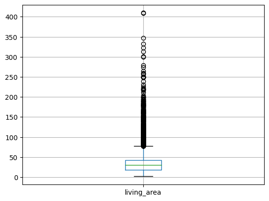

```python
data.boxplot(column='living_area')
plt.show()
```

Заполнение пропусков в столбце `living_area` — жилая площадь в квадратных метрах (м²) не является очевидной из этого набора данных. Но из жизненного опыта и таблицы зависимости столбцов друг от друга, мы знаем, что жилая площадь главным образом зависит от общей площади (`total_area`)и количества комнат(`rooms`). Эти столбцы не имеют пропусков.

Поэтому мы можем заполнить пропуски по категориям. Категории будем определять по количеству комнат. Далее вычислим отношение медианной жилой площади и медианной общей площади. И использую это отношение посчитаем жилую площадь от общей площади для каждого пропущенного значения.

```python
# проверим корректность данных по комнатам
data['rooms'].value_counts()
```

```
1     8047
2     7940
3     5814
4     1180
5      326
0      197
6      105
7       59
8       12
9        8
10       3
11       2
14       2
19       1
16       1
12       1
15       1
Name: rooms, dtype: int64
```

```python
for rooms in data['rooms'].unique():
    ratio_living_total_area = (data.loc[data['rooms'] == rooms, 'living_area'].median()
                                / data.loc[data['rooms'] == rooms, 'total_area'].median())
    # display (rooms, median_living_area_rooms)
    data.loc[(data['living_area'].isna()) & (data['rooms'] == rooms), 'living_area'] = (ratio_living_total_area
                                * data.loc[(data['living_area'].isna()) & (data['rooms'] == rooms), 'total_area'])
```

```python
data.loc[data['total_area'] < data['living_area']].head() # проверка, что жилая площадь меньше общей площади
```

|  | total_images | last_price | total_area | first_day_exposition | rooms | ceiling_height | floors_total | living_area | floor | is_apartment | ... | kitchen_area | balcony | locality_name | airports_nearest | city_centers_nearest | parks_around3000 | parks_nearest | ponds_around3000 | ponds_nearest | days_exposition |
| --- | --- | --- | --- | --- | --- | --- | --- | --- | --- | --- | --- | --- | --- | --- | --- | --- | --- | --- | --- | --- | --- |

0 rows × 22 columns

```python
data['living_area'].describe()
```

```
count    23699.000000
mean        34.637431
std         22.748419
min          2.000000
25%         18.700000
50%         30.000000
75%         42.300000
max        427.546729
Name: living_area, dtype: float64
```

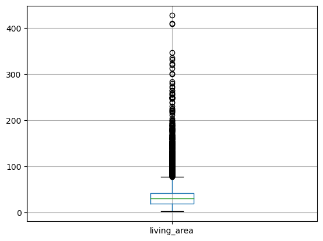

```python
data.boxplot(column='living_area')
plt.show()
```

```python
data[data['living_area'] > 300]
```

|  | total_images | last_price | total_area | first_day_exposition | rooms | ceiling_height | floors_total | living_area | floor | is_apartment | ... | kitchen_area | balcony | locality_name | airports_nearest | city_centers_nearest | parks_around3000 | parks_nearest | ponds_around3000 | ponds_nearest | days_exposition |
| --- | --- | --- | --- | --- | --- | --- | --- | --- | --- | --- | --- | --- | --- | --- | --- | --- | --- | --- | --- | --- | --- |
| 660 | 3 | 49950000.0 | 483.9 | 2017-10-04T00:00:00 | 7 | 3.20 | 6.0 | 312.500000 | 4 | NaN | ... | 26.4 | NaN | Санкт-Петербург | 23079.0 | 945.0 | 3.0 | 461.0 | 3.0 | 22.0 | 391.0 |
| 3117 | 19 | 140000000.0 | 631.0 | 2019-03-30T00:00:00 | 7 | 2.65 | 5.0 | 427.546729 | 5 | NaN | ... | 60.0 | NaN | Санкт-Петербург | 25707.0 | 4972.0 | 0.0 | NaN | 2.0 | 210.0 | NaN |
| 4237 | 1 | 50000000.0 | 517.0 | 2017-10-14T00:00:00 | 7 | 2.65 | 4.0 | 332.000000 | 3 | NaN | ... | 22.0 | NaN | Санкт-Петербург | 22835.0 | 1847.0 | 2.0 | 477.0 | 2.0 | 540.0 | NaN |
| 5358 | 20 | 65000000.0 | 590.0 | 2019-02-14T00:00:00 | 15 | 3.50 | 6.0 | 409.000000 | 3 | NaN | ... | 100.0 | NaN | Санкт-Петербург | 24447.0 | 4666.0 | 1.0 | 767.0 | 0.0 | NaN | 14.0 |
| 5893 | 3 | 230000000.0 | 500.0 | 2017-05-31T00:00:00 | 6 | 2.65 | 7.0 | 336.136734 | 7 | NaN | ... | 40.0 | 0.0 | Санкт-Петербург | 32440.0 | 5297.0 | 0.0 | NaN | 2.0 | 198.0 | 50.0 |
| 8018 | 20 | 84000000.0 | 507.0 | 2015-12-17T00:00:00 | 5 | 4.45 | 7.0 | 301.500000 | 7 | True | ... | 45.5 | 1.0 | Санкт-Петербург | NaN | 5735.0 | 2.0 | 110.0 | 0.0 | NaN | 1078.0 |
| 12401 | 20 | 91500000.0 | 495.0 | 2017-06-19T00:00:00 | 7 | 4.65 | 7.0 | 347.500000 | 7 | NaN | ... | 25.0 | 0.0 | Санкт-Петербург | NaN | 5735.0 | 2.0 | 110.0 | 0.0 | NaN | 14.0 |
| 12859 | 20 | 140000000.0 | 631.2 | 2019-04-09T00:00:00 | 7 | 3.90 | 4.0 | 322.300000 | 4 | NaN | ... | 19.5 | 1.0 | Санкт-Петербург | 25707.0 | 4972.0 | 0.0 | NaN | 2.0 | 210.0 | NaN |
| 15016 | 8 | 150000000.0 | 500.0 | 2016-01-13T00:00:00 | 4 | 3.20 | 7.0 | 320.241692 | 7 | NaN | ... | NaN | 0.0 | Санкт-Петербург | 33058.0 | 6150.0 | 3.0 | 209.0 | 3.0 | 531.0 | 303.0 |
| 19540 | 8 | 420000000.0 | 900.0 | 2017-12-06T00:00:00 | 12 | 2.80 | 25.0 | 409.700000 | 25 | NaN | ... | 112.0 | NaN | Санкт-Петербург | 30706.0 | 7877.0 | 0.0 | NaN | 2.0 | 318.0 | 106.0 |

10 rows × 22 columns

Проверили, насколько наши замены изменили описание столбца. Данные поменялись не значительно, но у нас увеличилось значение с 409,7 до 427,5 метров квадратных. Вот повезло кому-то ... еще и с общей площадью...В Питере... комунальные квартиры? Тем не менее данные хороши.

```python
display(f'Процент будликатов от общего числа данных {data.duplicated().sum() / len(data):.0%}')
```

```
'Процент будликатов от общего числа данных 0%'
```

##### `floors_total` — всего этажей в доме

```python
data[data['floors_total'].isna()].head()
```

|  | total_images | last_price | total_area | first_day_exposition | rooms | ceiling_height | floors_total | living_area | floor | is_apartment | ... | kitchen_area | balcony | locality_name | airports_nearest | city_centers_nearest | parks_around3000 | parks_nearest | ponds_around3000 | ponds_nearest | days_exposition |
| --- | --- | --- | --- | --- | --- | --- | --- | --- | --- | --- | --- | --- | --- | --- | --- | --- | --- | --- | --- | --- | --- |
| 186 | 12 | 11640000.0 | 65.2 | 2018-10-02T00:00:00 | 2 | 2.65 | NaN | 30.800000 | 4 | NaN | ... | 12.00 | NaN | Санкт-Петербург | 39197.0 | 12373.0 | 1.0 | 123.0 | 0.0 | NaN | 49.0 |
| 237 | 4 | 2438033.0 | 28.1 | 2016-11-23T00:00:00 | 1 | 2.65 | NaN | 20.750000 | 1 | NaN | ... | NaN | 0.0 | Санкт-Петербург | 22041.0 | 17369.0 | 0.0 | NaN | 1.0 | 374.0 | 251.0 |
| 457 | 4 | 9788348.0 | 70.8 | 2015-08-01T00:00:00 | 2 | 2.65 | NaN | 38.400000 | 12 | NaN | ... | 10.63 | 0.0 | Санкт-Петербург | 37364.0 | 8322.0 | 2.0 | 309.0 | 2.0 | 706.0 | 727.0 |
| 671 | 4 | 6051191.0 | 93.6 | 2017-04-06T00:00:00 | 3 | 2.65 | NaN | 47.100000 | 8 | NaN | ... | 16.80 | 0.0 | Санкт-Петербург | 22041.0 | 17369.0 | 0.0 | NaN | 1.0 | 374.0 | 123.0 |
| 1757 | 5 | 3600000.0 | 39.0 | 2017-04-22T00:00:00 | 1 | 2.65 | NaN | 18.774617 | 9 | NaN | ... | NaN | 0.0 | Санкт-Петербург | 22735.0 | 11618.0 | 1.0 | 835.0 | 1.0 | 652.0 | 77.0 |

5 rows × 22 columns

```python
nan_floors_total = data['floors_total'].isna().sum() / len(data)
display(f'Процент пропусков от общего числа данных {nan_floors_total:.0%}')
```

```
'Процент пропусков от общего числа данных 0%'
```

```python
data['floors_total'].value_counts()
```

```
5.0     5788
9.0     3761
16.0    1376
12.0    1362
4.0     1200
10.0    1174
25.0    1075
6.0      914
17.0     833
3.0      668
7.0      592
14.0     553
18.0     505
24.0     469
8.0      390
2.0      383
15.0     365
23.0     352
19.0     339
22.0     286
20.0     271
13.0     229
11.0     203
27.0     164
21.0     158
26.0     124
1.0       25
35.0      24
28.0      21
36.0       3
37.0       1
34.0       1
33.0       1
60.0       1
29.0       1
52.0       1
Name: floors_total, dtype: int64
```

```python
data['floors_total'].describe()
```

```
count    23613.000000
mean        10.673824
std          6.597173
min          1.000000
25%          5.000000
50%          9.000000
75%         16.000000
max         60.000000
Name: floors_total, dtype: float64
```

```python
# data.boxplot(column='floors_total')
# plt.show()
```

Так как в столбце `floors_total` — всего этажей в доме пропусков менее 1%, а логичных данных для замены нет, то я не буду делать замену пропусков. Если это скажется на результатах исследования, то мы можем вернуться к этому вопросу позже.

```python
display(f'Процент будликатов от общего числа данных {data.duplicated().sum() / len(data):.0%}')
```

```
'Процент будликатов от общего числа данных 0%'
```

##### `is_apartment` — апартаменты (булев тип)

```python
nan_is_apartment = data['is_apartment'].isna().sum() / len(data)
display(f'Процент пропусков от общего числа данных {nan_is_apartment:.0%}')
```

```
'Процент пропусков от общего числа данных 88%'
```

```python
data['is_apartment'].value_counts()
```

```
False    2725
True       50
Name: is_apartment, dtype: int64
```

```python
data[data['is_apartment'].isna()].head()
```

|  | total_images | last_price | total_area | first_day_exposition | rooms | ceiling_height | floors_total | living_area | floor | is_apartment | ... | kitchen_area | balcony | locality_name | airports_nearest | city_centers_nearest | parks_around3000 | parks_nearest | ponds_around3000 | ponds_nearest | days_exposition |
| --- | --- | --- | --- | --- | --- | --- | --- | --- | --- | --- | --- | --- | --- | --- | --- | --- | --- | --- | --- | --- | --- |
| 0 | 20 | 13000000.0 | 108.0 | 2019-03-07T00:00:00 | 3 | 2.70 | 16.0 | 51.000000 | 8 | NaN | ... | 25.0 | NaN | Санкт-Петербург | 18863.0 | 16028.0 | 1.0 | 482.0 | 2.0 | 755.0 | NaN |
| 1 | 7 | 3350000.0 | 40.4 | 2018-12-04T00:00:00 | 1 | 2.65 | 11.0 | 18.600000 | 1 | NaN | ... | 11.0 | 2.0 | посёлок Шушары | 12817.0 | 18603.0 | 0.0 | NaN | 0.0 | NaN | 81.0 |
| 2 | 10 | 5196000.0 | 56.0 | 2015-08-20T00:00:00 | 2 | 2.65 | 5.0 | 34.300000 | 4 | NaN | ... | 8.3 | 0.0 | Санкт-Петербург | 21741.0 | 13933.0 | 1.0 | 90.0 | 2.0 | 574.0 | 558.0 |
| 3 | 0 | 64900000.0 | 159.0 | 2015-07-24T00:00:00 | 3 | 2.65 | 14.0 | 98.013699 | 9 | NaN | ... | NaN | 0.0 | Санкт-Петербург | 28098.0 | 6800.0 | 2.0 | 84.0 | 3.0 | 234.0 | 424.0 |
| 4 | 2 | 10000000.0 | 100.0 | 2018-06-19T00:00:00 | 2 | 3.03 | 14.0 | 32.000000 | 13 | NaN | ... | 41.0 | NaN | Санкт-Петербург | 31856.0 | 8098.0 | 2.0 | 112.0 | 1.0 | 48.0 | 121.0 |

5 rows × 22 columns

```python
data[data['is_apartment'] == True].head()
```

|  | total_images | last_price | total_area | first_day_exposition | rooms | ceiling_height | floors_total | living_area | floor | is_apartment | ... | kitchen_area | balcony | locality_name | airports_nearest | city_centers_nearest | parks_around3000 | parks_nearest | ponds_around3000 | ponds_nearest | days_exposition |
| --- | --- | --- | --- | --- | --- | --- | --- | --- | --- | --- | --- | --- | --- | --- | --- | --- | --- | --- | --- | --- | --- |
| 543 | 11 | 12790000.0 | 56.6 | 2018-11-06T00:00:00 | 2 | 3.50 | 3.0 | 29.400000 | 1 | True | ... | NaN | NaN | Петергоф | 35248.0 | 30437.0 | 3.0 | 53.0 | 3.0 | 22.0 | NaN |
| 916 | 11 | 8183000.0 | 70.0 | 2018-01-11T00:00:00 | 2 | 3.12 | 3.0 | 40.000000 | 3 | True | ... | NaN | 2.0 | Санкт-Петербург | 45796.0 | 21729.0 | 0.0 | NaN | 1.0 | 754.0 | 179.0 |
| 1109 | 1 | 34878556.0 | 95.8 | 2014-12-09T00:00:00 | 2 | 2.65 | 6.0 | 58.300000 | 5 | True | ... | 20.0 | 1.0 | Санкт-Петербург | 21860.0 | 318.0 | 2.0 | 160.0 | 3.0 | 569.0 | 1572.0 |
| 1608 | 12 | 2150000.0 | 20.1 | 2019-01-30T00:00:00 | 1 | 2.65 | 9.0 | 9.676149 | 1 | True | ... | NaN | NaN | Санкт-Петербург | 26646.0 | 12147.0 | 0.0 | NaN | 0.0 | NaN | 13.0 |
| 2759 | 11 | 7500000.0 | 152.0 | 2018-07-27T00:00:00 | 3 | 3.00 | 3.0 | 93.698630 | 1 | True | ... | NaN | 1.0 | Всеволожск | NaN | NaN | NaN | NaN | NaN | NaN | 7.0 |

5 rows × 22 columns

Как мы видим столбец `is_apartment` — апартаменты (булев тип) отображает является ли объект апартаментами, тоесть объектом, который приобретают для сдачи в наем или аренду, обычно такие объекты более дешевы в приобретении, но более дороги по налоговому обложению и содержанию. Этот тип недвижимости возник совсем недавно. Доля таких объектов незначительно. В рамках нашего исследования мы можем предположить, что все пропущенные значения означают, что объект недвижимости не является апартаментами.

Замечение: При строительстве здания сразу определяется, что недвижимость в нем будет апартаментами. Тогда мы имея информацию о местоположении можем четко определить здания с апартаментами. Но в данном случае у нас этой информации нет. Привязка к другим данным маловероятна.

Заменим все пропуженные значения на False.

```python
data['is_apartment'] = data['is_apartment'].fillna(False)
data['is_apartment'].value_counts()
```

```
False    23649
True        50
Name: is_apartment, dtype: int64
```

```python
nan_is_apartment = data['is_apartment'].isna().sum() / len(data)
display(f'Процент пропусков от общего числа данных {nan_is_apartment:.0%}')
```

```
'Процент пропусков от общего числа данных 0%'
```

```python
data['is_apartment'].mean() # Доля апартаментов в общей базе
```

```
0.0021097936621798387
```

```python
display(f'Процент будликатов от общего числа данных {data.duplicated().sum() / len(data):.0%}')
```

```
'Процент будликатов от общего числа данных 0%'
```

##### `kitchen_area` — площадь кухни в квадратных метрах (м²)

```python
nan_kitchen_area = data['kitchen_area'].isna().sum() / len(data)
display(f'Процент пропусков от общего числа данных {nan_kitchen_area:.0%}')
```

```
'Процент пропусков от общего числа данных 10%'
```

```python
data['kitchen_area'].value_counts().head(20)
```

```
6.0     1300
10.0    1262
8.0     1110
9.0     1101
7.0     1062
11.0     797
12.0     662
8.5      415
5.5      400
14.0     381
5.0      358
15.0     351
13.0     323
6.3      296
6.2      282
8.3      272
6.5      263
8.2      235
7.5      232
8.4      214
Name: kitchen_area, dtype: int64
```

```python
data['kitchen_area'].describe()
```

```
count    21421.000000
mean        10.569807
std          5.905438
min          1.300000
25%          7.000000
50%          9.100000
75%         12.000000
max        112.000000
Name: kitchen_area, dtype: float64
```

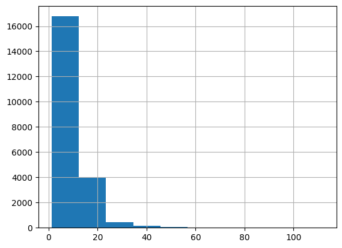

```python
data['kitchen_area'].hist(bins=10)
plt.show()
```

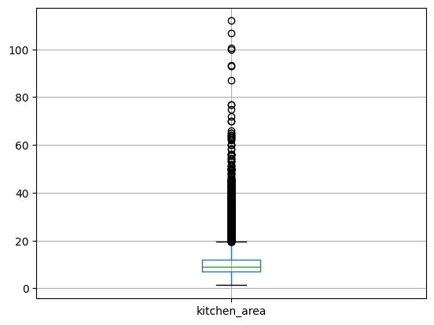

```python
data.boxplot(column='kitchen_area')
plt.show()
```

В столбце `kitchen_area` — площадь кухни в квадратных метрах (м²) около 10% пропусков. Среднее и медианные значения очень близки. Но стандратное отклонение больше половины среднего значения. Это говорит о том что в наборе есть ОЧЕНЬ БОЛЬШИЕ КУХНИ. Как мы уже знаем у нас действительно есть эксклюзивные объекты. Но к Гипотизе 1...

**Гипотиза 2**: В нашем наборе данных большое количество кухнь с площадью более 25 квадратных метров. Возможно при внесении этих данных был утерян десятичный разделитель. И эти данные следует исправить, разделив на 10.

Заменим пропуски 1/3 от нежилой площади. (проверили, что для большенства разнокомнатных квартир это верно, а с медианами не очень выходит)

```python
# Замена на медиану
# kitchen_area_median = data['kitchen_area'].median()
data.loc[data['kitchen_area'].isna(), 'kitchen_area'] = (data.loc[data['kitchen_area'].isna(), 'total_area'] - data.loc[data['kitchen_area'].isna(), 'living_area']) /3

# проверим число пропусков
nan_kitchen_area = data['kitchen_area'].isna().sum() / len(data)
display(f'Процент пропусков от общего числа данных {nan_kitchen_area:.0%}')
```

```
'Процент пропусков от общего числа данных 0%'
```

```python
data['kitchen_area'].describe()
```

```
count    23699.000000
mean        10.298228
std          5.912592
min          0.000000
25%          7.000000
50%          9.000000
75%         11.700000
max        112.000000
Name: kitchen_area, dtype: float64
```

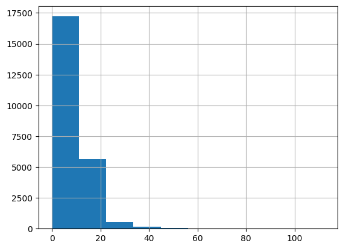

```python
data['kitchen_area'].hist(bins=10)
plt.show()
```

```python
display(f'Процент будликатов от общего числа данных {data.duplicated().sum() / len(data):.0%}')
```

```
'Процент будликатов от общего числа данных 0%'
```

Замены прошли удачно.

##### `balcony` — число балконов

```python
nan_balcony = data['balcony'].isna().sum() / len(data)
display(f'Процент пропусков от общего числа данных {nan_balcony:.0%}')
```

```
'Процент пропусков от общего числа данных 49%'
```

```python
data['balcony'].value_counts().head(20)
```

```
1.0    4195
0.0    3758
2.0    3659
5.0     304
4.0     183
3.0      81
Name: balcony, dtype: int64
```

```python
data['balcony'].describe()
```

```
count    12180.000000
mean         1.150082
std          1.071300
min          0.000000
25%          0.000000
50%          1.000000
75%          2.000000
max          5.000000
Name: balcony, dtype: float64
```

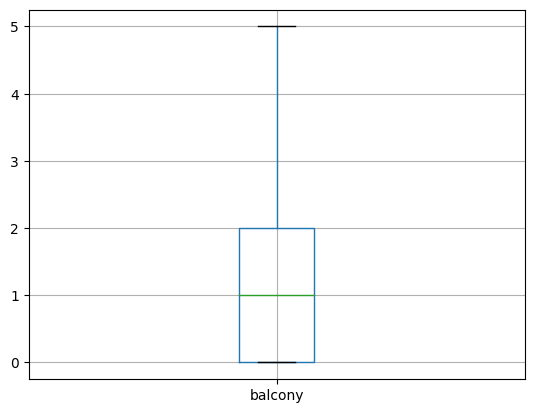

```python
data.boxplot(column='balcony')
plt.show()
```

Логично предположить, что в столбце `balcony` — число балконов пропущенные значения означают, что балконы в этом объекте недвижимости отсутствуют.

Поэтому произведем замену пропущенных значений на 0.

```python
# Сделаем замену
data['balcony'] = data['balcony'].fillna(0)
# Проверим
nan_balcony = data['balcony'].isna().sum() / len(data)
display(f'Процент пропусков от общего числа данных {nan_balcony:.0%}')
```

```
'Процент пропусков от общего числа данных 0%'
```

##### `locality_name` — название населённого пункта

```python
nan_locality_name = data['locality_name'].isna().sum() / len(data)
display(f'Процент пропусков от общего числа данных {nan_locality_name:.1%}')
```

```
'Процент пропусков от общего числа данных 0.2%'
```

```python
data['locality_name'].value_counts().head(20)
```

```
Санкт-Петербург            15721
посёлок Мурино               522
посёлок Шушары               440
Всеволожск                   398
Пушкин                       369
Колпино                      338
посёлок Парголово            327
Гатчина                      307
деревня Кудрово              299
Выборг                       237
Петергоф                     201
Сестрорецк                   183
Красное Село                 178
Кудрово                      173
деревня Новое Девяткино      144
Сертолово                    142
Ломоносов                    133
Кириши                       125
Сланцы                       112
Волхов                       111
Name: locality_name, dtype: int64
```

```python
data[data['locality_name'].isna()].head()
```

|  | total_images | last_price | total_area | first_day_exposition | rooms | ceiling_height | floors_total | living_area | floor | is_apartment | ... | kitchen_area | balcony | locality_name | airports_nearest | city_centers_nearest | parks_around3000 | parks_nearest | ponds_around3000 | ponds_nearest | days_exposition |
| --- | --- | --- | --- | --- | --- | --- | --- | --- | --- | --- | --- | --- | --- | --- | --- | --- | --- | --- | --- | --- | --- |
| 1097 | 3 | 8600000.0 | 81.7 | 2016-04-15T00:00:00 | 3 | 3.55 | 5.0 | 50.8 | 2 | False | ... | 8.8 | 0.0 | NaN | 23478.0 | 4258.0 | 0.0 | NaN | 0.0 | NaN | 147.0 |
| 2033 | 6 | 5398000.0 | 80.0 | 2017-05-30T00:00:00 | 3 | 2.65 | 4.0 | 42.6 | 2 | False | ... | 18.6 | 0.0 | NaN | NaN | NaN | NaN | NaN | NaN | NaN | 34.0 |
| 2603 | 20 | 3351765.0 | 42.7 | 2015-09-20T00:00:00 | 1 | 2.65 | 24.0 | 15.6 | 3 | False | ... | 10.7 | 0.0 | NaN | 22041.0 | 17369.0 | 0.0 | NaN | 1.0 | 374.0 | 276.0 |
| 2632 | 2 | 5130593.0 | 62.4 | 2015-10-11T00:00:00 | 2 | 2.65 | 24.0 | 33.1 | 21 | False | ... | 8.2 | 0.0 | NaN | 22041.0 | 17369.0 | 0.0 | NaN | 1.0 | 374.0 | 256.0 |
| 3574 | 10 | 4200000.0 | 46.5 | 2016-05-28T00:00:00 | 2 | 2.65 | 5.0 | 30.8 | 5 | False | ... | 6.5 | 0.0 | NaN | 27419.0 | 8127.0 | 0.0 | NaN | 1.0 | 603.0 | 45.0 |

5 rows × 22 columns

```python
data['locality_name'].unique()
```

```
array(['Санкт-Петербург', 'посёлок Шушары', 'городской посёлок Янино-1',
       'посёлок Парголово', 'посёлок Мурино', 'Ломоносов', 'Сертолово',
       'Петергоф', 'Пушкин', 'деревня Кудрово', 'Коммунар', 'Колпино',
       'поселок городского типа Красный Бор', 'Гатчина', 'поселок Мурино',
       'деревня Фёдоровское', 'Выборг', 'Кронштадт', 'Кировск',
       'деревня Новое Девяткино', 'посёлок Металлострой',
       'посёлок городского типа Лебяжье',
       'посёлок городского типа Сиверский', 'поселок Молодцово',
       'поселок городского типа Кузьмоловский',
       'садовое товарищество Новая Ропша', 'Павловск',
       'деревня Пикколово', 'Всеволожск', 'Волхов', 'Кингисепп',
       'Приозерск', 'Сестрорецк', 'деревня Куттузи', 'посёлок Аннино',
       'поселок городского типа Ефимовский', 'посёлок Плодовое',
       'деревня Заклинье', 'поселок Торковичи', 'поселок Первомайское',
       'Красное Село', 'посёлок Понтонный', 'Сясьстрой', 'деревня Старая',
       'деревня Лесколово', 'посёлок Новый Свет', 'Сланцы',
       'село Путилово', 'Ивангород', 'Мурино', 'Шлиссельбург',
       'Никольское', 'Зеленогорск', 'Сосновый Бор', 'поселок Новый Свет',
       'деревня Оржицы', 'деревня Кальтино', 'Кудрово',
       'поселок Романовка', 'посёлок Бугры', 'поселок Бугры',
       'поселок городского типа Рощино', 'Кириши', 'Луга', 'Волосово',
       'Отрадное', 'село Павлово', 'поселок Оредеж', 'село Копорье',
       'посёлок городского типа Красный Бор', 'посёлок Молодёжное',
       'Тихвин', 'посёлок Победа', 'деревня Нурма',
       'поселок городского типа Синявино', 'Тосно',
       'посёлок городского типа Кузьмоловский', 'посёлок Стрельна',
       'Бокситогорск', 'посёлок Александровская', 'деревня Лопухинка',
       'Пикалёво', 'поселок Терволово',
       'поселок городского типа Советский', 'Подпорожье',
       'посёлок Петровское', 'посёлок городского типа Токсово',
       'поселок Сельцо', 'посёлок городского типа Вырица',
       'деревня Кипень', 'деревня Келози', 'деревня Вартемяги',
       'посёлок Тельмана', 'поселок Севастьяново',
       'городской поселок Большая Ижора', nan,
       'городской посёлок Павлово', 'деревня Агалатово',
       'посёлок Новогорелово', 'городской посёлок Лесогорский',
       'деревня Лаголово', 'поселок Цвелодубово',
       'поселок городского типа Рахья', 'поселок городского типа Вырица',
       'деревня Белогорка', 'поселок Заводской',
       'городской посёлок Новоселье', 'деревня Большие Колпаны',
```

[output cut: 92 more lines]

```
       'деревня Ям-Тесово', 'деревня Раздолье', 'деревня Терпилицы',
       'посёлок Шугозеро', 'деревня Ваганово', 'поселок Пушное',
       'садовое товарищество Садко', 'посёлок Усть-Ижора',
       'деревня Выскатка', 'городской посёлок Свирьстрой',
       'поселок Громово', 'деревня Кисельня', 'посёлок Старая Малукса',
       'деревня Трубников Бор', 'поселок Калитино',
       'посёлок Высокоключевой', 'садовое товарищество Приладожский',
       'посёлок Пансионат Зелёный Бор', 'деревня Ненимяки',
       'поселок Пансионат Зелёный Бор', 'деревня Снегирёвка',
       'деревня Рапполово', 'деревня Пустынка', 'поселок Рабитицы',
       'деревня Большой Сабск', 'деревня Русско', 'деревня Лупполово',
       'деревня Большое Рейзино', 'деревня Малая Романовка',
       'поселок Дружноселье', 'поселок Пчевжа', 'поселок Володарское',
       'деревня Нижняя', 'коттеджный посёлок Лесное', 'деревня Тихковицы',
       'деревня Борисова Грива', 'посёлок Дзержинского'], dtype=object)
```

Из информации выше мы видим, что в столбце `locality_name` — название населённого пункта, есть следующие проблемы:

- пропуски, но их только 0.2% или 49 штук
- многие типы населенных пунктов записаны по разному, например, *поселок* и *посёлок* и другие.

Для решения задачи с пропусками мы можем использовать связь столбца `locality_name` и столбцов:

- `airports_nearest`
- `city_centers_nearest`
- `parks_around3000`
- `parks_nearest`
- `ponds_around3000`
- `ponds_nearest`

Но там много пропусков, возможно, мы используем обратную связь для их заполнения. Но это в будущем. А сейчас мы побережём силы и просто удалим 49 строк.

**Гипотеза 3** В столбце `locality_name` названия населенных пунктов записаны по разному, например, например, *поселок* и *посёлок* и другие. Мы решим эту задачу на этапе борьбы с аномалиями.

```python
# удаление строк с пропусками в названиях населенных пунктов
data = data.dropna(subset=['locality_name'])
# проверка
# data.info()
```

##### Инфраструктура

```python
data.isna().sum()
```

```
total_images                0
last_price                  0
total_area                  0
first_day_exposition        0
rooms                       0
ceiling_height              0
floors_total               85
living_area                 0
floor                       0
is_apartment                0
studio                      0
open_plan                   0
kitchen_area                0
balcony                     0
locality_name               0
airports_nearest         5534
city_centers_nearest     5511
parks_around3000         5510
parks_nearest           15586
ponds_around3000         5510
ponds_nearest           14565
days_exposition          3180
dtype: int64
```

Заметим, что у столбцов:

- `airports_nearest`
- `city_centers_nearest`
- `parks_around3000`
- `parks_nearest`
- `ponds_around3000`
- `ponds_nearest`

кроме логичной связи, есть еще очень похожее количество пропусков. Давайте разберемся с этим поглубже.

Начнем с растояния от цента города: `city_centers_nearest`

```python
data.loc[data['city_centers_nearest'].isna()].count()
```

```
total_images            5511
last_price              5511
total_area              5511
first_day_exposition    5511
rooms                   5511
ceiling_height          5511
floors_total            5501
living_area             5511
floor                   5511
is_apartment            5511
studio                  5511
open_plan               5511
kitchen_area            5511
balcony                 5511
locality_name           5511
airports_nearest           1
city_centers_nearest       0
parks_around3000           1
parks_nearest              1
ponds_around3000           1
ponds_nearest              0
days_exposition         4646
dtype: int64
```

```python
data.loc[(data['city_centers_nearest'].isna()) & (data['locality_name'] != 'Санкт-Петербург')].count()
```

```
total_images            5450
last_price              5450
total_area              5450
first_day_exposition    5450
rooms                   5450
ceiling_height          5450
floors_total            5441
living_area             5450
floor                   5450
is_apartment            5450
studio                  5450
open_plan               5450
kitchen_area            5450
balcony                 5450
locality_name           5450
airports_nearest           1
city_centers_nearest       0
parks_around3000           1
parks_nearest              1
ponds_around3000           1
ponds_nearest              0
days_exposition         4621
dtype: int64
```

```python
data.loc[(data['city_centers_nearest'].isna()) & (data['locality_name'] == 'Санкт-Петербург')].count()
```

```
total_images            61
last_price              61
total_area              61
first_day_exposition    61
rooms                   61
ceiling_height          61
floors_total            60
living_area             61
floor                   61
is_apartment            61
studio                  61
open_plan               61
kitchen_area            61
balcony                 61
locality_name           61
airports_nearest         0
city_centers_nearest     0
parks_around3000         0
parks_nearest            0
ponds_around3000         0
ponds_nearest            0
days_exposition         25
dtype: int64
```

```python
data.loc[(data['city_centers_nearest'].isna()) & (data['locality_name'] == 'Санкт-Петербург')].head()
```

|  | total_images | last_price | total_area | first_day_exposition | rooms | ceiling_height | floors_total | living_area | floor | is_apartment | ... | kitchen_area | balcony | locality_name | airports_nearest | city_centers_nearest | parks_around3000 | parks_nearest | ponds_around3000 | ponds_nearest | days_exposition |
| --- | --- | --- | --- | --- | --- | --- | --- | --- | --- | --- | --- | --- | --- | --- | --- | --- | --- | --- | --- | --- | --- |
| 81 | 9 | 10949000.0 | 68.0 | 2018-12-27T00:00:00 | 1 | 2.65 | 10.0 | 32.73523 | 6 | False | ... | 11.754923 | 0.0 | Санкт-Петербург | NaN | NaN | NaN | NaN | NaN | NaN | NaN |
| 593 | 20 | 4200000.0 | 38.3 | 2019-04-16T00:00:00 | 1 | 2.60 | 16.0 | 19.80000 | 10 | False | ... | 10.100000 | 2.0 | Санкт-Петербург | NaN | NaN | NaN | NaN | NaN | NaN | NaN |
| 604 | 11 | 9899000.0 | 101.0 | 2018-12-12T00:00:00 | 3 | 3.00 | 5.0 | 62.00000 | 3 | False | ... | 15.000000 | 0.0 | Санкт-Петербург | NaN | NaN | NaN | NaN | NaN | NaN | NaN |
| 742 | 7 | 37000000.0 | 161.0 | 2016-05-22T00:00:00 | 3 | 2.65 | 9.0 | 84.00000 | 8 | False | ... | 25.666667 | 0.0 | Санкт-Петербург | NaN | NaN | NaN | NaN | NaN | NaN | 402.0 |
| 795 | 19 | 7100000.0 | 59.6 | 2019-02-13T00:00:00 | 2 | 3.40 | 5.0 | 36.60000 | 2 | False | ... | 12.500000 | 0.0 | Санкт-Петербург | NaN | NaN | NaN | NaN | NaN | NaN | NaN |

5 rows × 22 columns

Логично предположить, что для населенных пунктов вне Санкт-Петербурга географические данные о парках и водоемах не собирали активно, так как это не мегаполисы, и эти факторы не так влияют на цену значительно. Оставим пропуски в этом столбце для населенных пунктов не являющимися мегаполисами.

Давайте исправим ситуацию с 61 пропущенным значением в Санкт-Петербурге: используем медиану.

```python
spb_city_centers_nearest_median = data.loc[data['locality_name'] == 'Санкт-Петербург', 'city_centers_nearest'].median()
# display (spb_city_centers_nearest_median)
data.loc[(data['city_centers_nearest'].isna()) & (data['locality_name'] == 'Санкт-Петербург') , 'city_centers_nearest'] = (
                                spb_city_centers_nearest_median)
# проверка
data.loc[(data['city_centers_nearest'].isna()) & (data['locality_name'] == 'Санкт-Петербург')].count()
```

```
total_images            0
last_price              0
total_area              0
first_day_exposition    0
rooms                   0
ceiling_height          0
floors_total            0
living_area             0
floor                   0
is_apartment            0
studio                  0
open_plan               0
kitchen_area            0
balcony                 0
locality_name           0
airports_nearest        0
city_centers_nearest    0
parks_around3000        0
parks_nearest           0
ponds_around3000        0
ponds_nearest           0
days_exposition         0
dtype: int64
```

Проверим заполненность наших столбцов для Санкт-Петербурга.

**`airports_nearest` — расстояние до ближайшего аэропорта в метрах (м)**

```python
data.loc[(data['airports_nearest'].isna()) & (data['locality_name'] == 'Санкт-Петербург')].count()
```

```
total_images            85
last_price              85
total_area              85
first_day_exposition    85
rooms                   85
ceiling_height          85
floors_total            84
living_area             85
floor                   85
is_apartment            85
studio                  85
open_plan               85
kitchen_area            85
balcony                 85
locality_name           85
airports_nearest         0
city_centers_nearest    85
parks_around3000        24
parks_nearest           20
ponds_around3000        24
ponds_nearest            8
days_exposition         47
dtype: int64
```

```python
data.loc[(data['airports_nearest'].isna()) & (data['locality_name'] == 'Санкт-Петербург')].head()
```

|  | total_images | last_price | total_area | first_day_exposition | rooms | ceiling_height | floors_total | living_area | floor | is_apartment | ... | kitchen_area | balcony | locality_name | airports_nearest | city_centers_nearest | parks_around3000 | parks_nearest | ponds_around3000 | ponds_nearest | days_exposition |
| --- | --- | --- | --- | --- | --- | --- | --- | --- | --- | --- | --- | --- | --- | --- | --- | --- | --- | --- | --- | --- | --- |
| 81 | 9 | 10949000.0 | 68.0 | 2018-12-27T00:00:00 | 1 | 2.65 | 10.0 | 32.73523 | 6 | False | ... | 11.754923 | 0.0 | Санкт-Петербург | NaN | 12244.5 | NaN | NaN | NaN | NaN | NaN |
| 593 | 20 | 4200000.0 | 38.3 | 2019-04-16T00:00:00 | 1 | 2.60 | 16.0 | 19.80000 | 10 | False | ... | 10.100000 | 2.0 | Санкт-Петербург | NaN | 12244.5 | NaN | NaN | NaN | NaN | NaN |
| 604 | 11 | 9899000.0 | 101.0 | 2018-12-12T00:00:00 | 3 | 3.00 | 5.0 | 62.00000 | 3 | False | ... | 15.000000 | 0.0 | Санкт-Петербург | NaN | 12244.5 | NaN | NaN | NaN | NaN | NaN |
| 733 | 18 | 18700000.0 | 109.7 | 2018-02-03T00:00:00 | 3 | 2.75 | 21.0 | 57.20000 | 13 | False | ... | 15.300000 | 1.0 | Санкт-Петербург | NaN | 13355.0 | 1.0 | 735.0 | 0.0 | NaN | 112.0 |
| 742 | 7 | 37000000.0 | 161.0 | 2016-05-22T00:00:00 | 3 | 2.65 | 9.0 | 84.00000 | 8 | False | ... | 25.666667 | 0.0 | Санкт-Петербург | NaN | 12244.5 | NaN | NaN | NaN | NaN | 402.0 |

5 rows × 22 columns

Так как пропусков в столбце `airports_nearest` — расстояние до ближайшего аэропорта в метрах (м) для Санкт-Петербурга мало то используем медиану для замены.

```python
spb_airports_nearest_median = data.loc[data['locality_name'] == 'Санкт-Петербург', 'airports_nearest'].median()
# display (spb_city_centers_nearest_median)
data.loc[(data['airports_nearest'].isna()) & (data['locality_name'] == 'Санкт-Петербург') , 'airports_nearest'] = (
                                spb_airports_nearest_median)
# проверка
data.loc[(data['airports_nearest'].isna()) & (data['locality_name'] == 'Санкт-Петербург')].count()
```

```
total_images            0
last_price              0
total_area              0
first_day_exposition    0
rooms                   0
ceiling_height          0
floors_total            0
living_area             0
floor                   0
is_apartment            0
studio                  0
open_plan               0
kitchen_area            0
balcony                 0
locality_name           0
airports_nearest        0
city_centers_nearest    0
parks_around3000        0
parks_nearest           0
ponds_around3000        0
ponds_nearest           0
days_exposition         0
dtype: int64
```

**`parks_around3000` — число парков в радиусе 3 км**

```python
data.loc[(data['parks_around3000'].isna()) & (data['locality_name'] == 'Санкт-Петербург')].count()
```

```
total_images            61
last_price              61
total_area              61
first_day_exposition    61
rooms                   61
ceiling_height          61
floors_total            60
living_area             61
floor                   61
is_apartment            61
studio                  61
open_plan               61
kitchen_area            61
balcony                 61
locality_name           61
airports_nearest        61
city_centers_nearest    61
parks_around3000         0
parks_nearest            0
ponds_around3000         0
ponds_nearest            0
days_exposition         25
dtype: int64
```

```python
data.loc[(data['parks_around3000'].isna()) & (data['locality_name'] == 'Санкт-Петербург')].head()
```

|  | total_images | last_price | total_area | first_day_exposition | rooms | ceiling_height | floors_total | living_area | floor | is_apartment | ... | kitchen_area | balcony | locality_name | airports_nearest | city_centers_nearest | parks_around3000 | parks_nearest | ponds_around3000 | ponds_nearest | days_exposition |
| --- | --- | --- | --- | --- | --- | --- | --- | --- | --- | --- | --- | --- | --- | --- | --- | --- | --- | --- | --- | --- | --- |
| 81 | 9 | 10949000.0 | 68.0 | 2018-12-27T00:00:00 | 1 | 2.65 | 10.0 | 32.73523 | 6 | False | ... | 11.754923 | 0.0 | Санкт-Петербург | 26757.5 | 12244.5 | NaN | NaN | NaN | NaN | NaN |
| 593 | 20 | 4200000.0 | 38.3 | 2019-04-16T00:00:00 | 1 | 2.60 | 16.0 | 19.80000 | 10 | False | ... | 10.100000 | 2.0 | Санкт-Петербург | 26757.5 | 12244.5 | NaN | NaN | NaN | NaN | NaN |
| 604 | 11 | 9899000.0 | 101.0 | 2018-12-12T00:00:00 | 3 | 3.00 | 5.0 | 62.00000 | 3 | False | ... | 15.000000 | 0.0 | Санкт-Петербург | 26757.5 | 12244.5 | NaN | NaN | NaN | NaN | NaN |
| 742 | 7 | 37000000.0 | 161.0 | 2016-05-22T00:00:00 | 3 | 2.65 | 9.0 | 84.00000 | 8 | False | ... | 25.666667 | 0.0 | Санкт-Петербург | 26757.5 | 12244.5 | NaN | NaN | NaN | NaN | 402.0 |
| 795 | 19 | 7100000.0 | 59.6 | 2019-02-13T00:00:00 | 2 | 3.40 | 5.0 | 36.60000 | 2 | False | ... | 12.500000 | 0.0 | Санкт-Петербург | 26757.5 | 12244.5 | NaN | NaN | NaN | NaN | NaN |

5 rows × 22 columns

Так как пропусков в столбце `parks_around3000` — число парков в радиусе 3 км для Санкт-Петербурга мало то используем медиану для замены.

```python
spb_parks_around3000_median = data.loc[data['locality_name'] == 'Санкт-Петербург', 'parks_around3000'].median()
display (spb_parks_around3000_median)
data.loc[(data['parks_around3000'].isna()) & (data['locality_name'] == 'Санкт-Петербург') , 'parks_around3000'] = (
                                spb_parks_around3000_median)
# проверка
data.loc[(data['parks_around3000'].isna()) & (data['locality_name'] == 'Санкт-Петербург')].count()
```

```
0.0
```

```
total_images            0
last_price              0
total_area              0
first_day_exposition    0
rooms                   0
ceiling_height          0
floors_total            0
living_area             0
floor                   0
is_apartment            0
studio                  0
open_plan               0
kitchen_area            0
balcony                 0
locality_name           0
airports_nearest        0
city_centers_nearest    0
parks_around3000        0
parks_nearest           0
ponds_around3000        0
ponds_nearest           0
days_exposition         0
dtype: int64
```

**`ponds_around3000` — число водоёмов в радиусе 3 км**

```python
data.loc[(data['ponds_around3000'].isna()) & (data['locality_name'] == 'Санкт-Петербург')].count()
```

```
total_images            61
last_price              61
total_area              61
first_day_exposition    61
rooms                   61
ceiling_height          61
floors_total            60
living_area             61
floor                   61
is_apartment            61
studio                  61
open_plan               61
kitchen_area            61
balcony                 61
locality_name           61
airports_nearest        61
city_centers_nearest    61
parks_around3000        61
parks_nearest            0
ponds_around3000         0
ponds_nearest            0
days_exposition         25
dtype: int64
```

Аналогично: медиана.

```python
spb_ponds_around3000_median = data.loc[data['locality_name'] == 'Санкт-Петербург', 'ponds_around3000'].median()
display (spb_ponds_around3000_median)
data.loc[(data['ponds_around3000'].isna()) & (data['locality_name'] == 'Санкт-Петербург') , 'ponds_around3000'] = (
                                spb_ponds_around3000_median)
# проверка
data.loc[(data['ponds_around3000'].isna()) & (data['locality_name'] == 'Санкт-Петербург')].count()
```

```
1.0
```

```
total_images            0
last_price              0
total_area              0
first_day_exposition    0
rooms                   0
ceiling_height          0
floors_total            0
living_area             0
floor                   0
is_apartment            0
studio                  0
open_plan               0
kitchen_area            0
balcony                 0
locality_name           0
airports_nearest        0
city_centers_nearest    0
parks_around3000        0
parks_nearest           0
ponds_around3000        0
ponds_nearest           0
days_exposition         0
dtype: int64
```

Северная Венеция: в 3 км парков 0, водоемов 1!

Посмотрим, что у нас расстояниями до парков и водоемов.

**`parks_nearest` — расстояние до ближайшего парка (м)**

```python
data['parks_nearest'].describe()
```

```
count    8064.000000
mean      490.830729
std       342.554386
min         1.000000
25%       288.000000
50%       454.500000
75%       612.000000
max      3190.000000
Name: parks_nearest, dtype: float64
```

```python
data.loc[(data['locality_name'] == 'Санкт-Петербург'), 'parks_nearest'].describe()
```

```
count    7284.000000
mean      498.597886
std       345.181284
min         1.000000
25%       295.000000
50%       460.000000
75%       619.000000
max      3190.000000
Name: parks_nearest, dtype: float64
```

```python
data.loc[(data['locality_name'] != 'Санкт-Петербург'), 'parks_nearest'].describe()
```

```
count     780.000000
mean      418.297436
std       307.850444
min         4.000000
25%       226.000000
50%       374.500000
75%       531.000000
max      2131.000000
Name: parks_nearest, dtype: float64
```

```python
data[data['parks_nearest'].isna()].head()
```

|  | total_images | last_price | total_area | first_day_exposition | rooms | ceiling_height | floors_total | living_area | floor | is_apartment | ... | kitchen_area | balcony | locality_name | airports_nearest | city_centers_nearest | parks_around3000 | parks_nearest | ponds_around3000 | ponds_nearest | days_exposition |
| --- | --- | --- | --- | --- | --- | --- | --- | --- | --- | --- | --- | --- | --- | --- | --- | --- | --- | --- | --- | --- | --- |
| 1 | 7 | 3350000.0 | 40.40 | 2018-12-04T00:00:00 | 1 | 2.65 | 11.0 | 18.600000 | 1 | False | ... | 11.00 | 2.0 | посёлок Шушары | 12817.0 | 18603.0 | 0.0 | NaN | 0.0 | NaN | 81.0 |
| 5 | 10 | 2890000.0 | 30.40 | 2018-09-10T00:00:00 | 1 | 2.65 | 12.0 | 14.400000 | 5 | False | ... | 9.10 | 0.0 | городской посёлок Янино-1 | NaN | NaN | NaN | NaN | NaN | NaN | 55.0 |
| 6 | 6 | 3700000.0 | 37.30 | 2017-11-02T00:00:00 | 1 | 2.65 | 26.0 | 10.600000 | 6 | False | ... | 14.40 | 1.0 | посёлок Парголово | 52996.0 | 19143.0 | 0.0 | NaN | 0.0 | NaN | 155.0 |
| 7 | 5 | 7915000.0 | 71.60 | 2019-04-18T00:00:00 | 2 | 2.65 | 24.0 | 41.203774 | 22 | False | ... | 18.90 | 2.0 | Санкт-Петербург | 23982.0 | 11634.0 | 0.0 | NaN | 0.0 | NaN | NaN |
| 8 | 20 | 2900000.0 | 33.16 | 2018-05-23T00:00:00 | 1 | 2.65 | 27.0 | 15.430000 | 26 | False | ... | 8.81 | 0.0 | посёлок Мурино | NaN | NaN | NaN | NaN | NaN | NaN | 189.0 |

5 rows × 22 columns

Похоже, что, если парк не в Санкт-Петербурге или в Санкт-Петербурге дальше 3 км, то расстояние до него и не определяли.

Хотя нет... Вот они 4 исключения! И все в Санкт-Петербурге!

Большого влияния они не оказывают. Нам известны. Пусть остаются.

```python
data.loc[(data['parks_nearest'] > 3000) & (data['parks_around3000'] == 0), 'parks_nearest'].describe()
```

```
count       4.000000
mean     3114.250000
std        89.912457
min      3013.000000
25%      3051.250000
50%      3127.000000
75%      3190.000000
max      3190.000000
Name: parks_nearest, dtype: float64
```

```python
data.loc[(data['parks_nearest'] > 3000) & (data['parks_around3000'] == 0)]
```

|  | total_images | last_price | total_area | first_day_exposition | rooms | ceiling_height | floors_total | living_area | floor | is_apartment | ... | kitchen_area | balcony | locality_name | airports_nearest | city_centers_nearest | parks_around3000 | parks_nearest | ponds_around3000 | ponds_nearest | days_exposition |
| --- | --- | --- | --- | --- | --- | --- | --- | --- | --- | --- | --- | --- | --- | --- | --- | --- | --- | --- | --- | --- | --- |
| 1590 | 3 | 7500000.0 | 70.0 | 2017-07-11T00:00:00 | 2 | 2.65 | 18.0 | 37.0 | 13 | False | ... | 10.0 | 0.0 | Санкт-Петербург | 14878.0 | 9791.0 | 0.0 | 3064.0 | 1.0 | 264.0 | 4.0 |
| 10959 | 9 | 3000000.0 | 31.1 | 2017-03-21T00:00:00 | 1 | 2.65 | 5.0 | 17.7 | 2 | False | ... | 5.5 | 0.0 | Санкт-Петербург | 14821.0 | 9734.0 | 0.0 | 3190.0 | 1.0 | 431.0 | 234.0 |
| 19208 | 17 | 14950000.0 | 187.0 | 2017-10-12T00:00:00 | 5 | 3.00 | 2.0 | 80.0 | 2 | False | ... | 17.0 | 1.0 | Санкт-Петербург | 36805.0 | 8656.0 | 0.0 | 3013.0 | 3.0 | 537.0 | 49.0 |
| 19430 | 9 | 3900000.0 | 30.5 | 2018-02-22T00:00:00 | 1 | 2.60 | 5.0 | 16.5 | 1 | False | ... | 5.5 | 0.0 | Санкт-Петербург | 14821.0 | 9734.0 | 0.0 | 3190.0 | 1.0 | 431.0 | 176.0 |

4 rows × 22 columns

**`ponds_nearest` — расстояние до ближайшего водоёма (м)**

```python
data['ponds_nearest'].describe()
```

```
count    9085.000000
mean      518.059879
std       277.841733
min        13.000000
25%       293.000000
50%       502.000000
75%       730.000000
max      1344.000000
Name: ponds_nearest, dtype: float64
```

```python
data.loc[(data['locality_name'] == 'Санкт-Петербург'), 'ponds_nearest'].describe()
```

```
count    7983.000000
mean      520.213955
std       280.260745
min        13.000000
25%       293.000000
50%       503.000000
75%       738.000000
max      1337.000000
Name: ponds_nearest, dtype: float64
```

```python
data.loc[(data['locality_name'] != 'Санкт-Петербург'), 'ponds_nearest'].describe()
```

```
count    1102.000000
mean      502.455535
std       259.231904
min        22.000000
25%       298.000000
50%       488.500000
75%       666.000000
max      1344.000000
Name: ponds_nearest, dtype: float64
```

```python
data[data['ponds_nearest'].isna()].head()
```

|  | total_images | last_price | total_area | first_day_exposition | rooms | ceiling_height | floors_total | living_area | floor | is_apartment | ... | kitchen_area | balcony | locality_name | airports_nearest | city_centers_nearest | parks_around3000 | parks_nearest | ponds_around3000 | ponds_nearest | days_exposition |
| --- | --- | --- | --- | --- | --- | --- | --- | --- | --- | --- | --- | --- | --- | --- | --- | --- | --- | --- | --- | --- | --- |
| 1 | 7 | 3350000.0 | 40.40 | 2018-12-04T00:00:00 | 1 | 2.65 | 11.0 | 18.600000 | 1 | False | ... | 11.00 | 2.0 | посёлок Шушары | 12817.0 | 18603.0 | 0.0 | NaN | 0.0 | NaN | 81.0 |
| 5 | 10 | 2890000.0 | 30.40 | 2018-09-10T00:00:00 | 1 | 2.65 | 12.0 | 14.400000 | 5 | False | ... | 9.10 | 0.0 | городской посёлок Янино-1 | NaN | NaN | NaN | NaN | NaN | NaN | 55.0 |
| 6 | 6 | 3700000.0 | 37.30 | 2017-11-02T00:00:00 | 1 | 2.65 | 26.0 | 10.600000 | 6 | False | ... | 14.40 | 1.0 | посёлок Парголово | 52996.0 | 19143.0 | 0.0 | NaN | 0.0 | NaN | 155.0 |
| 7 | 5 | 7915000.0 | 71.60 | 2019-04-18T00:00:00 | 2 | 2.65 | 24.0 | 41.203774 | 22 | False | ... | 18.90 | 2.0 | Санкт-Петербург | 23982.0 | 11634.0 | 0.0 | NaN | 0.0 | NaN | NaN |
| 8 | 20 | 2900000.0 | 33.16 | 2018-05-23T00:00:00 | 1 | 2.65 | 27.0 | 15.430000 | 26 | False | ... | 8.81 | 0.0 | посёлок Мурино | NaN | NaN | NaN | NaN | NaN | NaN | 189.0 |

5 rows × 22 columns

```python
data.loc[(data['ponds_nearest'] > 3000) & (data['ponds_around3000'] == 0), 'ponds_nearest'].describe()
```

```
count    0.0
mean     NaN
std      NaN
min      NaN
25%      NaN
50%      NaN
75%      NaN
max      NaN
Name: ponds_nearest, dtype: float64
```

В столбце `ponds_nearest` — расстояние до ближайшего водоёма (м) все аналогично расстояниям до парков. Только еще и исключений нет.

```python
data.isna().sum()
```

```
total_images                0
last_price                  0
total_area                  0
first_day_exposition        0
rooms                       0
ceiling_height              0
floors_total               85
living_area                 0
floor                       0
is_apartment                0
studio                      0
open_plan                   0
kitchen_area                0
balcony                     0
locality_name               0
airports_nearest         5449
city_centers_nearest     5450
parks_around3000         5449
parks_nearest           15586
ponds_around3000         5449
ponds_nearest           14565
days_exposition          3180
dtype: int64
```

##### `days_exposition` — сколько дней было размещено объявление (от публикации до снятия)

```python
nan_days_exposition = data['days_exposition'].isna().sum() / len(data)
display(f'Процент пропусков от общего числа данных {nan_days_exposition:.0%}')
```

```
'Процент пропусков от общего числа данных 13%'
```

```python
data['days_exposition'].value_counts().head()
```

```
45.0    879
60.0    538
7.0     234
30.0    208
90.0    203
Name: days_exposition, dtype: int64
```

```python
data['days_exposition'].describe()
```

```
count    20470.000000
mean       180.753200
std        219.777916
min          1.000000
25%         45.000000
50%         95.000000
75%        231.000000
max       1580.000000
Name: days_exposition, dtype: float64
```

```python
data[data['days_exposition'].isna()].head()
```

|  | total_images | last_price | total_area | first_day_exposition | rooms | ceiling_height | floors_total | living_area | floor | is_apartment | ... | kitchen_area | balcony | locality_name | airports_nearest | city_centers_nearest | parks_around3000 | parks_nearest | ponds_around3000 | ponds_nearest | days_exposition |
| --- | --- | --- | --- | --- | --- | --- | --- | --- | --- | --- | --- | --- | --- | --- | --- | --- | --- | --- | --- | --- | --- |
| 0 | 20 | 13000000.0 | 108.0 | 2019-03-07T00:00:00 | 3 | 2.70 | 16.0 | 51.000000 | 8 | False | ... | 25.000000 | 0.0 | Санкт-Петербург | 18863.0 | 16028.0 | 1.0 | 482.0 | 2.0 | 755.0 | NaN |
| 7 | 5 | 7915000.0 | 71.6 | 2019-04-18T00:00:00 | 2 | 2.65 | 24.0 | 41.203774 | 22 | False | ... | 18.900000 | 2.0 | Санкт-Петербург | 23982.0 | 11634.0 | 0.0 | NaN | 0.0 | NaN | NaN |
| 44 | 13 | 5350000.0 | 40.0 | 2018-11-18T00:00:00 | 1 | 2.65 | 22.0 | 19.256018 | 3 | False | ... | 6.914661 | 1.0 | Санкт-Петербург | 30471.0 | 11603.0 | 1.0 | 620.0 | 1.0 | 1152.0 | NaN |
| 45 | 17 | 5200000.0 | 50.6 | 2018-12-02T00:00:00 | 2 | 2.65 | 9.0 | 30.300000 | 7 | False | ... | 7.000000 | 0.0 | Санкт-Петербург | 30011.0 | 12872.0 | 0.0 | NaN | 0.0 | NaN | NaN |
| 46 | 17 | 6600000.0 | 52.1 | 2019-01-31T00:00:00 | 2 | 2.60 | 24.0 | 29.700000 | 9 | False | ... | 8.300000 | 2.0 | Санкт-Петербург | 15114.0 | 12702.0 | 0.0 | NaN | 0.0 | NaN | NaN |

5 rows × 22 columns

```python
data[~data['days_exposition'].isna()].head()
```

|  | total_images | last_price | total_area | first_day_exposition | rooms | ceiling_height | floors_total | living_area | floor | is_apartment | ... | kitchen_area | balcony | locality_name | airports_nearest | city_centers_nearest | parks_around3000 | parks_nearest | ponds_around3000 | ponds_nearest | days_exposition |
| --- | --- | --- | --- | --- | --- | --- | --- | --- | --- | --- | --- | --- | --- | --- | --- | --- | --- | --- | --- | --- | --- |
| 1 | 7 | 3350000.0 | 40.4 | 2018-12-04T00:00:00 | 1 | 2.65 | 11.0 | 18.600000 | 1 | False | ... | 11.000000 | 2.0 | посёлок Шушары | 12817.0 | 18603.0 | 0.0 | NaN | 0.0 | NaN | 81.0 |
| 2 | 10 | 5196000.0 | 56.0 | 2015-08-20T00:00:00 | 2 | 2.65 | 5.0 | 34.300000 | 4 | False | ... | 8.300000 | 0.0 | Санкт-Петербург | 21741.0 | 13933.0 | 1.0 | 90.0 | 2.0 | 574.0 | 558.0 |
| 3 | 0 | 64900000.0 | 159.0 | 2015-07-24T00:00:00 | 3 | 2.65 | 14.0 | 98.013699 | 9 | False | ... | 20.328767 | 0.0 | Санкт-Петербург | 28098.0 | 6800.0 | 2.0 | 84.0 | 3.0 | 234.0 | 424.0 |
| 4 | 2 | 10000000.0 | 100.0 | 2018-06-19T00:00:00 | 2 | 3.03 | 14.0 | 32.000000 | 13 | False | ... | 41.000000 | 0.0 | Санкт-Петербург | 31856.0 | 8098.0 | 2.0 | 112.0 | 1.0 | 48.0 | 121.0 |
| 5 | 10 | 2890000.0 | 30.4 | 2018-09-10T00:00:00 | 1 | 2.65 | 12.0 | 14.400000 | 5 | False | ... | 9.100000 | 0.0 | городской посёлок Янино-1 | NaN | NaN | NaN | NaN | NaN | NaN | 55.0 |

5 rows × 22 columns

С точки зрения заполнения пропусков столбец `days_exposition` — сколько дней было размещено объявление (от публикации до снятия) выглядит хорошо: 13% пропущенных значений. У нас есть еще столбец с датой начала публикации, но нет столбца с датой окончания публикации. Поэтому мы можем предположить, что наш столбец имеет пропуски там, где на момент взятия данных публикация еще не была снята.

Оставим пока эти пропуски в базе.

**Итоги:**

```python
data.isna().sum()
```

```
total_images                0
last_price                  0
total_area                  0
first_day_exposition        0
rooms                       0
ceiling_height              0
floors_total               85
living_area                 0
floor                       0
is_apartment                0
studio                      0
open_plan                   0
kitchen_area                0
balcony                     0
locality_name               0
airports_nearest         5449
city_centers_nearest     5450
parks_around3000         5449
parks_nearest           15586
ponds_around3000         5449
ponds_nearest           14565
days_exposition          3180
dtype: int64
```

```python
#data.info()
```

### Изменение типа данных столбцов

Оптимизация типов данных позволяет:

- экономить машинные ресурсы: память, время процессора,
- ускорять обработку данных,
- делает данные более понятными и наглядными для человека.

У столбца с балконами `balcony` тип данный вещественный. Хотя можем быть и целый. Произведем замену.

```python
data['balcony'] = data['balcony'].astype('int')
# Проверим
# data.info()
```

```python
data.loc[(data['last_price'] % 1) != 0, 'last_price'].count()
```

```
0
```

У столбца с последней ценой `last_price` тоже можно поменять тип данных с вещественного на целочисленный.

```python
data['last_price'] = data['last_price'].astype('int')
# Проверим
# data.info()
```

`first_day_exposition` столбец можно перевести в формат даты и времени.

```python
# проверим сколько строк заканчивается на '00:00:00'
display (data['first_day_exposition'].isin(['00:00:00']).sum())

data['first_day_exposition'] = pd.to_datetime(data['first_day_exposition'], format='%Y-%m-%dT%H:%M:%S')
# Проверим
# data.info()
# data['first_day_exposition'].head()
```

```
0
```

Со остальными столбцами разберёмся циклично и быстро. Столбцы:

- `floors_total`
- `airports_nearest`
- `city_centers_nearest`
- `parks_around3000`
- `parks_nearest`
- `ponds_around3000`
- `ponds_nearest`
- `days_exposition`

```python
columns = ['floors_total', 'airports_nearest', 'city_centers_nearest', 'parks_around3000', 'parks_nearest', 'ponds_around3000',\
           'ponds_nearest', 'days_exposition']

for column in columns:
    data[column] = np.floor(pd.to_numeric(data[column], errors='coerce')).astype('Int64')


# data['floors_total'] = pd.to_numeric(data['floors_total'], errors='coerce', downcast='signed')
data.info()
```

```
<class 'pandas.core.frame.DataFrame'>
Int64Index: 23650 entries, 0 to 23698
Data columns (total 22 columns):
 #   Column                Non-Null Count  Dtype
---  ------                --------------  -----
 0   total_images          23650 non-null  int64
 1   last_price            23650 non-null  int32
 2   total_area            23650 non-null  float64
 3   first_day_exposition  23650 non-null  datetime64[ns]
 4   rooms                 23650 non-null  int64
 5   ceiling_height        23650 non-null  float64
 6   floors_total          23565 non-null  Int64
 7   living_area           23650 non-null  float64
 8   floor                 23650 non-null  int64
 9   is_apartment          23650 non-null  bool
 10  studio                23650 non-null  bool
 11  open_plan             23650 non-null  bool
 12  kitchen_area          23650 non-null  float64
 13  balcony               23650 non-null  int32
 14  locality_name         23650 non-null  object
 15  airports_nearest      18201 non-null  Int64
 16  city_centers_nearest  18200 non-null  Int64
 17  parks_around3000      18201 non-null  Int64
 18  parks_nearest         8064 non-null   Int64
 19  ponds_around3000      18201 non-null  Int64
 20  ponds_nearest         9085 non-null   Int64
 21  days_exposition       20470 non-null  Int64
dtypes: Int64(8), bool(3), datetime64[ns](1), float64(4), int32(2), int64(3), object(1)
memory usage: 3.7+ MB
```

### Обработка гипотиз

#### Гипотиза 3 или борьба с неявными дубликатами

**Гипотеза 3** В столбце `locality_name` названия населенных пунктов записаны по разному, например, *Кудрово* и *деревня Кудрово*

```python
data['locality_name'].unique()
```

```
array(['Санкт-Петербург', 'посёлок Шушары', 'городской посёлок Янино-1',
       'посёлок Парголово', 'посёлок Мурино', 'Ломоносов', 'Сертолово',
       'Петергоф', 'Пушкин', 'деревня Кудрово', 'Коммунар', 'Колпино',
       'поселок городского типа Красный Бор', 'Гатчина', 'поселок Мурино',
       'деревня Фёдоровское', 'Выборг', 'Кронштадт', 'Кировск',
       'деревня Новое Девяткино', 'посёлок Металлострой',
       'посёлок городского типа Лебяжье',
       'посёлок городского типа Сиверский', 'поселок Молодцово',
       'поселок городского типа Кузьмоловский',
       'садовое товарищество Новая Ропша', 'Павловск',
       'деревня Пикколово', 'Всеволожск', 'Волхов', 'Кингисепп',
       'Приозерск', 'Сестрорецк', 'деревня Куттузи', 'посёлок Аннино',
       'поселок городского типа Ефимовский', 'посёлок Плодовое',
       'деревня Заклинье', 'поселок Торковичи', 'поселок Первомайское',
       'Красное Село', 'посёлок Понтонный', 'Сясьстрой', 'деревня Старая',
       'деревня Лесколово', 'посёлок Новый Свет', 'Сланцы',
       'село Путилово', 'Ивангород', 'Мурино', 'Шлиссельбург',
       'Никольское', 'Зеленогорск', 'Сосновый Бор', 'поселок Новый Свет',
       'деревня Оржицы', 'деревня Кальтино', 'Кудрово',
       'поселок Романовка', 'посёлок Бугры', 'поселок Бугры',
       'поселок городского типа Рощино', 'Кириши', 'Луга', 'Волосово',
       'Отрадное', 'село Павлово', 'поселок Оредеж', 'село Копорье',
       'посёлок городского типа Красный Бор', 'посёлок Молодёжное',
       'Тихвин', 'посёлок Победа', 'деревня Нурма',
       'поселок городского типа Синявино', 'Тосно',
       'посёлок городского типа Кузьмоловский', 'посёлок Стрельна',
       'Бокситогорск', 'посёлок Александровская', 'деревня Лопухинка',
       'Пикалёво', 'поселок Терволово',
       'поселок городского типа Советский', 'Подпорожье',
       'посёлок Петровское', 'посёлок городского типа Токсово',
       'поселок Сельцо', 'посёлок городского типа Вырица',
       'деревня Кипень', 'деревня Келози', 'деревня Вартемяги',
       'посёлок Тельмана', 'поселок Севастьяново',
       'городской поселок Большая Ижора', 'городской посёлок Павлово',
       'деревня Агалатово', 'посёлок Новогорелово',
       'городской посёлок Лесогорский', 'деревня Лаголово',
       'поселок Цвелодубово', 'поселок городского типа Рахья',
       'поселок городского типа Вырица', 'деревня Белогорка',
       'поселок Заводской', 'городской посёлок Новоселье',
       'деревня Большие Колпаны', 'деревня Горбунки', 'деревня Батово',
```

[output cut: 91 more lines]

```
       'деревня Ям-Тесово', 'деревня Раздолье', 'деревня Терпилицы',
       'посёлок Шугозеро', 'деревня Ваганово', 'поселок Пушное',
       'садовое товарищество Садко', 'посёлок Усть-Ижора',
       'деревня Выскатка', 'городской посёлок Свирьстрой',
       'поселок Громово', 'деревня Кисельня', 'посёлок Старая Малукса',
       'деревня Трубников Бор', 'поселок Калитино',
       'посёлок Высокоключевой', 'садовое товарищество Приладожский',
       'посёлок Пансионат Зелёный Бор', 'деревня Ненимяки',
       'поселок Пансионат Зелёный Бор', 'деревня Снегирёвка',
       'деревня Рапполово', 'деревня Пустынка', 'поселок Рабитицы',
       'деревня Большой Сабск', 'деревня Русско', 'деревня Лупполово',
       'деревня Большое Рейзино', 'деревня Малая Романовка',
       'поселок Дружноселье', 'поселок Пчевжа', 'поселок Володарское',
       'деревня Нижняя', 'коттеджный посёлок Лесное', 'деревня Тихковицы',
       'деревня Борисова Грива', 'посёлок Дзержинского'], dtype=object)
```

Из набора названий видно:

- все названия населенных пунктов указаны с большой буквы и последними в строке,
- у городов не указано, что это город,
- в названиях других населенных пунктов много вариантов написания, например е и ё, для посёлков может указываться городской тип в любом месте, а с поселками у жд станции и садовыми товариществами вообще беда.

Конечно, самый простой способ - это оставить только, то что после заглавной буквы. Но тогда все деревни и поселки будут как города. Устроит ли нас это при анализе? Скорее "нет" чем "да". Используем алгоритм посложнее.

```python
# Вхождение -- замена, и обращаем внимание на порядок слов и на последовательность замен

# "пос" --  "посёлок" v
# "кот" "пос" --  "посёлок"
# "пос" "гор" --  "посёлок городского типа" v v
# "пос" "гор" "имен" -- "посёлок городского типа имени"  v
# "пос" " станц" -- "посёлок при жд станции" v
# "дер"  -- "деревня" v
# "сел" -- "село" v
# "сад" "тов" -- "садовое товарищество" v v

data['locality_name'] = data['locality_name'].replace(regex=
                                                      {
                                                        r'^пос.+станции\s': 'посёлок при жд станции ',
                                                        r'^пос.+имени\s': 'посёлок городского типа имени ',
                                                        r'^садо.+тов.+\s': 'садовое товарищество ',
                                                        r'.*тов.+\s.*садо.+\s': 'садовое товарищество ',
                                                        r'^городск.*\s.*пос.+\s': 'посёлок городского типа ',
                                                        r'^пос.+\s.*городск.+\sтипа\s': 'посёлок городского типа ',
                                                        r'поселок': 'посёлок ',
                                                        r'^дер.+\s': 'деревня ',
                                                        # r'^сел.+\s': 'село '
                                                        r'\s+': ' ',
                                                        'деревня Кудрово': 'Кудрово'
                                                      }
                                                     )
# проверка
# data.loc[data['locality_name'].str.find('жд') > -1, 'locality_name'].value_counts()
data['locality_name'].unique()
```

```
array(['Санкт-Петербург', 'посёлок Шушары',
       'посёлок городского типа Янино-1', 'посёлок Парголово',
       'посёлок Мурино', 'Ломоносов', 'Сертолово', 'Петергоф', 'Пушкин',
       'Кудрово', 'Коммунар', 'Колпино',
       'посёлок городского типа Красный Бор', 'Гатчина',
       'деревня Фёдоровское', 'Выборг', 'Кронштадт', 'Кировск',
       'деревня Девяткино', 'посёлок Металлострой',
       'посёлок городского типа Лебяжье',
       'посёлок городского типа Сиверский', 'посёлок Молодцово',
       'посёлок городского типа Кузьмоловский',
       'садовое товарищество Ропша', 'Павловск', 'деревня Пикколово',
       'Всеволожск', 'Волхов', 'Кингисепп', 'Приозерск', 'Сестрорецк',
       'деревня Куттузи', 'посёлок Аннино',
       'посёлок городского типа Ефимовский', 'посёлок Плодовое',
       'деревня Заклинье', 'посёлок Торковичи', 'посёлок Первомайское',
       'Красное Село', 'посёлок Понтонный', 'Сясьстрой', 'деревня Старая',
       'деревня Лесколово', 'посёлок Новый Свет', 'Сланцы',
       'село Путилово', 'Ивангород', 'Мурино', 'Шлиссельбург',
       'Никольское', 'Зеленогорск', 'Сосновый Бор', 'деревня Оржицы',
       'деревня Кальтино', 'посёлок Романовка', 'посёлок Бугры',
       'посёлок городского типа Рощино', 'Кириши', 'Луга', 'Волосово',
       'Отрадное', 'село Павлово', 'посёлок Оредеж', 'село Копорье',
       'посёлок Молодёжное', 'Тихвин', 'посёлок Победа', 'деревня Нурма',
       'посёлок городского типа Синявино', 'Тосно', 'посёлок Стрельна',
       'Бокситогорск', 'посёлок Александровская', 'деревня Лопухинка',
       'Пикалёво', 'посёлок Терволово',
       'посёлок городского типа Советский', 'Подпорожье',
       'посёлок Петровское', 'посёлок городского типа Токсово',
       'посёлок Сельцо', 'посёлок городского типа Вырица',
       'деревня Кипень', 'деревня Келози', 'деревня Вартемяги',
       'посёлок Тельмана', 'посёлок Севастьяново',
       'посёлок городского типа Ижора', 'посёлок городского типа Павлово',
       'деревня Агалатово', 'посёлок Новогорелово',
       'посёлок городского типа Лесогорский', 'деревня Лаголово',
       'посёлок Цвелодубово', 'посёлок городского типа Рахья',
       'деревня Белогорка', 'посёлок Заводской',
       'посёлок городского типа Новоселье', 'деревня Колпаны',
       'деревня Горбунки', 'деревня Батово', 'деревня Заневка',
       'деревня Иссад', 'Приморск', 'посёлок городского типа Фёдоровское',
       'деревня Мистолово', 'Новая Ладога', 'посёлок Зимитицы',
```

[output cut: 68 more lines]

```
       'посёлок Плоское', 'посёлок городского типа Большая Ижора',
       'посёлок Кирпичное', 'деревня Ям-Тесово', 'деревня Раздолье',
       'деревня Терпилицы', 'посёлок Шугозеро', 'деревня Ваганово',
       'посёлок Пушное', 'садовое товарищество Садко',
       'посёлок Усть-Ижора', 'деревня Выскатка',
       'посёлок городского типа Свирьстрой', 'посёлок Громово',
       'деревня Кисельня', 'посёлок Калитино', 'посёлок Высокоключевой',
       'садовое товарищество Приладожский',
       'посёлок Пансионат Зелёный Бор', 'деревня Ненимяки',
       'деревня Снегирёвка', 'деревня Рапполово', 'деревня Пустынка',
       'посёлок Рабитицы', 'деревня Сабск', 'деревня Русско',
       'деревня Лупполово', 'деревня Рейзино', 'деревня Романовка',
       'посёлок Дружноселье', 'посёлок Пчевжа', 'посёлок Володарское',
       'деревня Нижняя', 'коттеджный посёлок Лесное', 'деревня Тихковицы',
       'деревня Грива', 'посёлок Дзержинского'], dtype=object)
```

Это была трудоемкая работа. В следующий раз попробуем лемматизатор...

```python
data['locality_name'].value_counts()
```

```
Санкт-Петербург                   15721
посёлок Мурино                      556
Кудрово                             472
посёлок Шушары                      440
Всеволожск                          398
                                  ...
коттеджный посёлок Счастье            1
деревня Меньково                      1
посёлок Гончарово                     1
деревня Рейзино                       1
посёлок при жд станции Корнево        1
Name: locality_name, Length: 317, dtype: int64
```

#### Гипотиза 1 или борьба с аномалиями с высотой потолков

**Гипотеза 1:** В области 20 - 40 метров обнаружено большое скопление данных, возможно эти данные введены без десятичного разделителя.

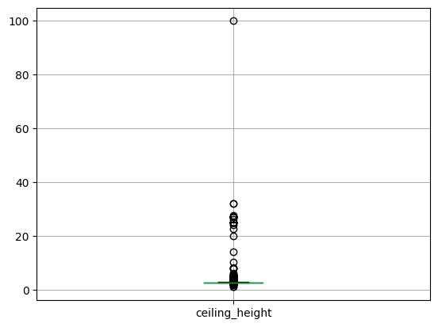

```python
data.boxplot(column='ceiling_height')
plt.show()
```

Мы можем расширить нашу задачу: давайте обработаем все потолки выше 4 метров. Для жилих помещений все это либо эксклюзив, либо ошибка.

И раз уж работаем с эксклюзивами, пусть минимальный потолок будет 2 метра.

```python
data.query('ceiling_height > 4').value_counts('ceiling_height')
```

```
ceiling_height
4.20      10
27.00      8
25.00      7
4.50       7
8.00       3
4.10       3
4.40       3
4.70       2
5.30       2
4.19       2
32.00      2
4.45       2
26.00      1
6.00       1
24.00      1
27.50      1
22.60      1
20.00      1
14.00      1
10.30      1
8.30       1
4.06       1
5.80       1
5.60       1
5.50       1
5.20       1
5.00       1
4.90       1
4.80       1
4.65       1
4.37       1
4.30       1
4.25       1
4.15       1
4.14       1
100.00     1
dtype: int64
```

Как мы видим у нас есть небольшое количество эклюзивных объектов недвижимости, но есть и ошибки данных. Различие в них в том, что, если разделить их на 10, то в ошибках будет значение больше минимальной высоты потолка, а в эксклюзивных объектах меньше. Исправим это.

```python
min_ceiling = 2
data['ceiling_height'].where(data['ceiling_height'] / 10 < min_ceiling, data['ceiling_height'] / 10, inplace=True)
data['ceiling_height'].describe()
```

```
count    23650.000000
mean         2.698620
std          0.253201
min          1.000000
25%          2.600000
50%          2.650000
75%          2.700000
max         14.000000
Name: ceiling_height, dtype: float64
```

Посмотрим еще раз на аномалии с низкими потолками или слишком высокими потолками и маленькими площадями для таких высоких потолков.

```python
data.loc[(data['ceiling_height'] < min_ceiling) | ((data['ceiling_height'] > 6) & (data['total_area'] < 80))]
```

|  | total_images | last_price | total_area | first_day_exposition | rooms | ceiling_height | floors_total | living_area | floor | is_apartment | ... | kitchen_area | balcony | locality_name | airports_nearest | city_centers_nearest | parks_around3000 | parks_nearest | ponds_around3000 | ponds_nearest | days_exposition |
| --- | --- | --- | --- | --- | --- | --- | --- | --- | --- | --- | --- | --- | --- | --- | --- | --- | --- | --- | --- | --- | --- |
| 3474 | 3 | 1400000 | 30.0 | 2018-03-16 | 1 | 8.00 | 5 | 15.3 | 2 | False | ... | 7.300000 | 0 | деревня Нурма | <NA> | <NA> | <NA> | <NA> | <NA> | <NA> | 125 |
| 5712 | 5 | 1500000 | 42.8 | 2017-08-14 | 2 | 1.20 | 2 | 27.5 | 1 | False | ... | 5.200000 | 0 | посёлок городского типа Мга | <NA> | <NA> | <NA> | <NA> | <NA> | <NA> | 248 |
| 5863 | 20 | 5650000 | 45.0 | 2018-08-15 | 1 | 8.30 | 16 | 19.3 | 14 | False | ... | 8.300000 | 1 | Санкт-Петербург | 13069 | 10763 | 0 | <NA> | 1 | 613 | 14 |
| 15061 | 19 | 5600000 | 56.4 | 2018-05-11 | 2 | 14.00 | 14 | 32.4 | 5 | False | ... | 9.100000 | 2 | Санкт-Петербург | 14814 | 13610 | 0 | <NA> | 0 | <NA> | 315 |
| 15743 | 14 | 5600000 | 67.0 | 2016-11-11 | 3 | 8.00 | 16 | 41.0 | 1 | False | ... | 8.000000 | 0 | Санкт-Петербург | 32691 | 11035 | 1 | 723 | 0 | <NA> | 474 |
| 16934 | 5 | 4100000 | 40.0 | 2017-10-17 | 1 | 1.75 | 37 | 17.4 | 5 | False | ... | 8.340000 | 0 | Санкт-Петербург | 18732 | 20444 | 0 | <NA> | 3 | 80 | 71 |
| 17442 | 0 | 5350000 | 54.0 | 2015-06-16 | 2 | 8.00 | 5 | 29.0 | 2 | False | ... | 8.333333 | 1 | Красное Село | 24638 | 28062 | 0 | <NA> | 0 | <NA> | 469 |
| 22309 | 20 | 5300000 | 45.0 | 2017-09-30 | 1 | 10.30 | 16 | 15.5 | 15 | False | ... | 9.833333 | 0 | Санкт-Петербург | 36353 | 11936 | 2 | 440 | 2 | 450 | 136 |
| 22590 | 16 | 6000000 | 55.0 | 2018-10-31 | 2 | 1.00 | 12 | 32.4 | 7 | False | ... | 10.000000 | 0 | Санкт-Петербург | 33053 | 14217 | 2 | 293 | 2 | 289 | 13 |
| 22869 | 0 | 15000000 | 25.0 | 2018-07-25 | 1 | 10.00 | 5 | 14.0 | 5 | True | ... | 11.000000 | 5 | Санкт-Петербург | 34963 | 8283 | 1 | 223 | 3 | 30 | 19 |

10 rows × 22 columns

И растанемся с ними без сожаления.

```python
data = data.loc[~((data['ceiling_height'] < min_ceiling) | ((data['ceiling_height'] > 6) & (data['total_area'] < 80)))]
# data.info()
data['ceiling_height'].describe()
```

```
count    23640.000000
mean         2.696777
std          0.221095
min          2.000000
25%          2.600000
50%          2.650000
75%          2.700000
max          6.000000
Name: ceiling_height, dtype: float64
```

До преобразований и после медиана осталась 2,65 метра. Будем считать, что мы удачно поборолись с пропусками и аномалиями.

#### Гипотиза 2 или борьба с аномалиями с площадью кухни

**Гипотиза 2**: В нашем наборе данных большое количество кухнь с площадью более 25 квадратных метров. Возможно при внесении этих данных был утерян десятичный разделитель. И эти данные слудует исправить, разделив на 10.

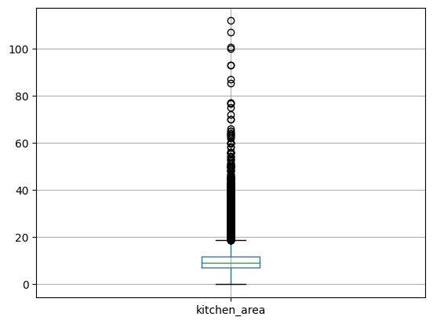

```python
data.boxplot(column='kitchen_area')
plt.show()
```

```python
data.query('kitchen_area >= total_area')['kitchen_area'].count()
```

```
0
```

У нас нет ситуаций, когда площадь кухни больше площади всей квартиры.

```python
data.query('kitchen_area >= living_area')['kitchen_area'].count()
```

```
400
```

Но есть квартиры где площадь кухни больше жилой площади. Хотя это и не так страшно.

```python
data.query('kitchen_area + living_area > total_area')['kitchen_area'].count()
```

```
73
```

А страшно, что есть квартиры, где сумма жилой площади и кухни больше общей площади. Такое могло произойти и при подготовке данных, но не по нашей вине, так наша формула этого бы не позволила.

Посмотрим на эти данные и безжалостно с ними расстанемся.

```python
display (data.query('kitchen_area + living_area > total_area').head())
data = data.query('kitchen_area + living_area <= total_area')
# проверка
data.query('kitchen_area + living_area > total_area')['kitchen_area'].count()
```

|  | total_images | last_price | total_area | first_day_exposition | rooms | ceiling_height | floors_total | living_area | floor | is_apartment | ... | kitchen_area | balcony | locality_name | airports_nearest | city_centers_nearest | parks_around3000 | parks_nearest | ponds_around3000 | ponds_nearest | days_exposition |
| --- | --- | --- | --- | --- | --- | --- | --- | --- | --- | --- | --- | --- | --- | --- | --- | --- | --- | --- | --- | --- | --- |
| 184 | 7 | 2600000 | 30.20 | 2018-02-14 | 1 | 2.65 | 9 | 26.10 | 5 | False | ... | 6.20 | 0 | Санкт-Петербург | 13952 | 15031 | 0 | <NA> | 1 | 824 | 12 |
| 545 | 9 | 4700000 | 23.80 | 2018-12-28 | 1 | 2.65 | 18 | 20.00 | 9 | False | ... | 5.00 | 0 | Санкт-Петербург | 9731 | 11849 | 0 | <NA> | 0 | <NA> | 108 |
| 551 | 8 | 3100000 | 31.59 | 2018-03-08 | 1 | 2.70 | 19 | 30.55 | 2 | False | ... | 9.28 | 2 | посёлок Мурино | <NA> | <NA> | <NA> | <NA> | <NA> | <NA> | 70 |
| 601 | 12 | 5600000 | 53.70 | 2017-04-18 | 2 | 2.50 | 12 | 48.30 | 5 | False | ... | 7.00 | 2 | Санкт-Петербург | 50477 | 13252 | 2 | 220 | 1 | 1250 | 167 |
| 696 | 1 | 3364930 | 34.69 | 2014-11-27 | 1 | 2.64 | 25 | 23.43 | 25 | False | ... | 23.43 | 2 | Санкт-Петербург | 43396 | 12153 | 0 | <NA> | 0 | <NA> | 574 |

5 rows × 22 columns

```
0
```

```python
data['kitchen_area'].describe()
```

```
count    23567.000000
mean        10.276675
std          5.880153
min          0.000000
25%          7.000000
50%          9.000000
75%         11.680000
max        112.000000
Name: kitchen_area, dtype: float64
```

```python
# data.query('kitchen_area > 30').head(20)
# data.query('kitchen_area >= living_area and kitchen_area > 30 and total_area <100')['kitchen_area'].describe()
# data.query('kitchen_area >= living_area and kitchen_area > 30 and total_area > 100').head(20)
data.query('(total_area - kitchen_area - living_area) / total_area > 0.5')['kitchen_area'].count()
```

```
73
```

В рамках борьбы с аномалиями и ошибками удалим квартиры, где площадь кладовок, туалетов, коридоров больше половины квартиры. Тем более их всего 73 и это не повлияет на основную статистику.

```python
data = data.query('~((total_area - kitchen_area - living_area) / total_area > 0.5)')
data.query('(total_area - kitchen_area - living_area) / total_area > 0.5')['kitchen_area'].count()
```

```
0
```

```python
data['kitchen_area'].describe()
```

```
count    23494.000000
mean        10.266225
std          5.874477
min          0.000000
25%          7.000000
50%          9.000000
75%         11.600000
max        112.000000
Name: kitchen_area, dtype: float64
```

Относительно **Гипотизы 2**: Есть понятие кухня-гостинная, из-за него можно признать, что эта Гипотиза не верна. Особенно в квартирах с большой площадью.

### Устранение редких и выбивающихся значений (аномалий) во всех столбцах

[output not shown]

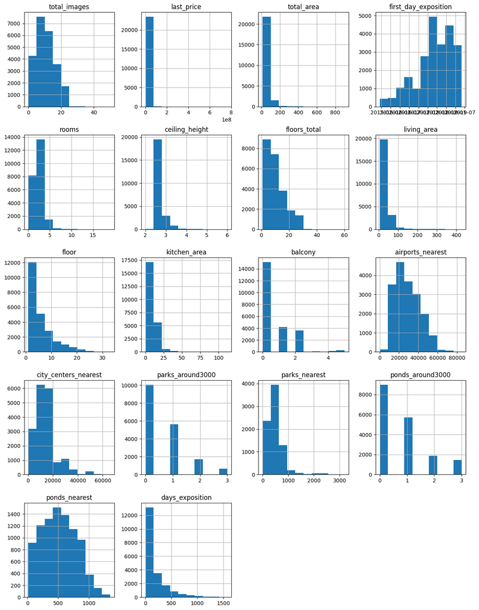

```python
data.hist(figsize=(15, 20))
```

```python
data.info()
```

```
<class 'pandas.core.frame.DataFrame'>
Int64Index: 23494 entries, 0 to 23698
Data columns (total 22 columns):
 #   Column                Non-Null Count  Dtype
---  ------                --------------  -----
 0   total_images          23494 non-null  int64
 1   last_price            23494 non-null  int32
 2   total_area            23494 non-null  float64
 3   first_day_exposition  23494 non-null  datetime64[ns]
 4   rooms                 23494 non-null  int64
 5   ceiling_height        23494 non-null  float64
 6   floors_total          23410 non-null  Int64
 7   living_area           23494 non-null  float64
 8   floor                 23494 non-null  int64
 9   is_apartment          23494 non-null  bool
 10  studio                23494 non-null  bool
 11  open_plan             23494 non-null  bool
 12  kitchen_area          23494 non-null  float64
 13  balcony               23494 non-null  int32
 14  locality_name         23494 non-null  object
 15  airports_nearest      18078 non-null  Int64
 16  city_centers_nearest  18077 non-null  Int64
 17  parks_around3000      18078 non-null  Int64
 18  parks_nearest         8012 non-null   Int64
 19  ponds_around3000      18078 non-null  Int64
 20  ponds_nearest         9024 non-null   Int64
 21  days_exposition       20337 non-null  Int64
dtypes: Int64(8), bool(3), datetime64[ns](1), float64(4), int32(2), int64(3), object(1)
memory usage: 3.7+ MB
```

На данном этапе удалено достаточно, выбивающие значения и пропуски имеют свое объяснение.

Сейчас мы оставляем пропущенные значения в`floors_total`. Из-за этого будут пропуски в определении типа этажа. Но допустимо решение с удалением этих строк, если это будет мешать вычислениям Расчеты с целесообразностью рассмотрены на этапе заполнения пропусков.

```python
# data = data[~data['floors_total'].isna()]
# data.info()
```

#### `rooms` и `studio` как это связано

```python
data.loc[(data['studio'] == True), 'rooms'].unique()
```

```
array([0, 1], dtype=int64)
```

```python
data.loc[(data['studio'] == True) & (data['rooms'] == 1)]
```

|  | total_images | last_price | total_area | first_day_exposition | rooms | ceiling_height | floors_total | living_area | floor | is_apartment | ... | kitchen_area | balcony | locality_name | airports_nearest | city_centers_nearest | parks_around3000 | parks_nearest | ponds_around3000 | ponds_nearest | days_exposition |
| --- | --- | --- | --- | --- | --- | --- | --- | --- | --- | --- | --- | --- | --- | --- | --- | --- | --- | --- | --- | --- | --- |
| 2389 | 5 | 2250000 | 25.41 | 2016-06-07 | 1 | 2.65 | 12 | 17.08 | 8 | False | ... | 2.776667 | 2 | Санкт-Петербург | 14125 | 12921 | 2 | 328 | 2 | 485 | 26 |
| 3187 | 13 | 3800000 | 27.00 | 2016-05-17 | 1 | 2.65 | 14 | 18.00 | 8 | False | ... | 3.000000 | 2 | Санкт-Петербург | 50348 | 16053 | 0 | <NA> | 0 | <NA> | 45 |
| 4180 | 4 | 4500000 | 34.00 | 2016-04-25 | 1 | 2.80 | 10 | 21.00 | 10 | False | ... | 4.333333 | 2 | Санкт-Петербург | 23609 | 5299 | 0 | <NA> | 1 | 433 | 62 |
| 8683 | 10 | 3500000 | 32.50 | 2016-05-05 | 1 | 3.00 | 23 | 29.90 | 11 | False | ... | 0.866667 | 2 | Санкт-Петербург | 34967 | 14640 | 0 | <NA> | 1 | 564 | 45 |
| 11026 | 1 | 2800000 | 28.00 | 2016-05-04 | 1 | 2.65 | 26 | 19.00 | 6 | False | ... | 3.000000 | 2 | посёлок Парголово | 53511 | 19687 | 0 | <NA> | 0 | <NA> | 45 |
| 12935 | 10 | 2200000 | 31.00 | 2016-05-15 | 1 | 2.50 | 8 | 22.30 | 5 | False | ... | 2.900000 | 1 | Никольское | <NA> | <NA> | <NA> | <NA> | <NA> | <NA> | 44 |
| 15142 | 2 | 2700000 | 30.00 | 2016-05-10 | 1 | 2.65 | 21 | 26.00 | 6 | False | ... | 1.333333 | 0 | Кудрово | <NA> | <NA> | <NA> | <NA> | <NA> | <NA> | 55 |
| 18732 | 4 | 2400000 | 22.00 | 2016-05-06 | 1 | 2.65 | 10 | 15.00 | 6 | False | ... | 2.333333 | 0 | Кудрово | <NA> | <NA> | <NA> | <NA> | <NA> | <NA> | 45 |
| 20086 | 0 | 1550000 | 22.00 | 2016-05-11 | 1 | 2.70 | 15 | 10.94 | 14 | False | ... | 3.686667 | 2 | Никольское | <NA> | <NA> | <NA> | <NA> | <NA> | <NA> | 45 |
| 21702 | 9 | 2349000 | 23.40 | 2016-05-19 | 1 | 2.70 | 20 | 16.00 | 8 | False | ... | 2.466667 | 1 | деревня Девяткино | <NA> | <NA> | <NA> | <NA> | <NA> | <NA> | 34 |
| 22652 | 5 | 2650000 | 26.00 | 2015-06-24 | 1 | 2.65 | 14 | 15.00 | 11 | False | ... | 3.666667 | 0 | посёлок Мурино | <NA> | <NA> | <NA> | <NA> | <NA> | <NA> | 373 |

11 rows × 22 columns

```python
data.loc[(data['studio'] == True) & (data['rooms'] == 0)].head()
```

|  | total_images | last_price | total_area | first_day_exposition | rooms | ceiling_height | floors_total | living_area | floor | is_apartment | ... | kitchen_area | balcony | locality_name | airports_nearest | city_centers_nearest | parks_around3000 | parks_nearest | ponds_around3000 | ponds_nearest | days_exposition |
| --- | --- | --- | --- | --- | --- | --- | --- | --- | --- | --- | --- | --- | --- | --- | --- | --- | --- | --- | --- | --- | --- |
| 144 | 1 | 2450000 | 27.00 | 2017-03-30 | 0 | 2.65 | 24 | 15.500000 | 2 | False | ... | 3.833333 | 2 | посёлок Мурино | <NA> | <NA> | <NA> | <NA> | <NA> | <NA> | 181 |
| 440 | 8 | 2480000 | 27.11 | 2018-03-12 | 0 | 2.65 | 17 | 24.750000 | 4 | False | ... | 0.786667 | 2 | Санкт-Петербург | 38171 | 15015 | 0 | <NA> | 2 | 982 | 64 |
| 608 | 2 | 1850000 | 25.00 | 2019-02-20 | 0 | 2.65 | 10 | 17.274472 | 7 | False | ... | 2.575176 | 0 | посёлок Шушары | <NA> | <NA> | <NA> | <NA> | <NA> | <NA> | 29 |
| 697 | 12 | 2500000 | 24.10 | 2017-12-01 | 0 | 2.75 | 25 | 17.500000 | 21 | False | ... | 2.200000 | 0 | Кудрово | <NA> | <NA> | <NA> | <NA> | <NA> | <NA> | 201 |
| 716 | 5 | 1500000 | 17.00 | 2017-06-07 | 0 | 2.70 | 9 | 12.000000 | 1 | False | ... | 1.666667 | 0 | посёлок Шушары | 18654 | 29846 | 0 | <NA> | 0 | <NA> | 40 |

5 rows × 22 columns

```python
data.loc[(data['studio'] == True) & (data['rooms'] == 0), 'studio'].count()
```

```
136
```

```python
data.loc[(data['studio'] == False), 'rooms'].unique()
```

```
array([ 3,  1,  2,  4,  5,  6,  0,  7, 11,  8, 14, 10, 15,  9, 19, 16, 12],
      dtype=int64)
```

```python
data.loc[(data['studio'] == False) & (data['rooms'] == 0)].head()
```

|  | total_images | last_price | total_area | first_day_exposition | rooms | ceiling_height | floors_total | living_area | floor | is_apartment | ... | kitchen_area | balcony | locality_name | airports_nearest | city_centers_nearest | parks_around3000 | parks_nearest | ponds_around3000 | ponds_nearest | days_exposition |
| --- | --- | --- | --- | --- | --- | --- | --- | --- | --- | --- | --- | --- | --- | --- | --- | --- | --- | --- | --- | --- | --- |
| 349 | 4 | 2320000 | 25.0 | 2017-09-27 | 0 | 2.65 | 14 | 17.000000 | 1 | False | ... | 2.666667 | 0 | Кудрово | <NA> | <NA> | <NA> | <NA> | <NA> | <NA> | 45 |
| 508 | 0 | 3375000 | 34.4 | 2017-03-28 | 0 | 2.65 | 26 | 24.300000 | 19 | False | ... | 3.366667 | 1 | посёлок Парголово | 53115 | 19292 | 0 | <NA> | 1 | 593 | 430 |
| 780 | 9 | 2600000 | 26.1 | 2018-02-20 | 0 | 2.65 | 18 | 18.034549 | 8 | False | ... | 2.688484 | 1 | посёлок Мурино | <NA> | <NA> | <NA> | <NA> | <NA> | <NA> | 45 |
| 839 | 14 | 1900000 | 35.0 | 2017-04-14 | 0 | 2.70 | 5 | 15.000000 | 3 | False | ... | 6.666667 | 1 | посёлок Новый Свет | <NA> | <NA> | <NA> | <NA> | <NA> | <NA> | 7 |
| 946 | 5 | 2200000 | 23.0 | 2016-09-27 | 0 | 2.65 | 27 | 18.000000 | 7 | False | ... | 1.666667 | 2 | посёлок Мурино | <NA> | <NA> | <NA> | <NA> | <NA> | <NA> | 483 |

5 rows × 22 columns

```python
data.loc[(data['studio'] == False) & (data['rooms'] == 0) & (data['living_area'] > 50)]
```

|  | total_images | last_price | total_area | first_day_exposition | rooms | ceiling_height | floors_total | living_area | floor | is_apartment | ... | kitchen_area | balcony | locality_name | airports_nearest | city_centers_nearest | parks_around3000 | parks_nearest | ponds_around3000 | ponds_nearest | days_exposition |
| --- | --- | --- | --- | --- | --- | --- | --- | --- | --- | --- | --- | --- | --- | --- | --- | --- | --- | --- | --- | --- | --- |
| 19392 | 5 | 71000000 | 371.0 | 2018-07-26 | 0 | 3.57 | 7 | 256.353167 | 6 | False | ... | 38.215611 | 0 | Санкт-Петербург | 25257 | 6060 | 1 | 761 | 1 | 584 | 90 |

1 rows × 22 columns

И так у нас странная ситуация:

- есть студии, которые имеют 0 или 1 комнату, по остальным параметрам явно не отличаются,
- ест не студии с 0 комнат, которые не отличаются от студий явно, кроме одной.

В рамках нашего исследования, учитывая, что доля данных крайне мала, примем следующие ограничения:

Учитывая выше изложенное актуальность, столбца `studio` утрачивается, но в наших алгоритмах мы его сохраним.

```python
data.loc[(data['studio'] == True) & (data['rooms'] == 1), 'rooms'] = 0
data.loc[(data['studio'] == True) & (data['rooms'] == 1), 'rooms'].count()
```

```
0
```

```python
data.loc[(data['studio'] == False) & (data['rooms'] == 0) & (data['living_area'] > 50), 'rooms'] = \
data.loc[(data['studio'] == False) & (data['rooms'] == 0) & (data['living_area'] > 50), 'living_area'] // 20

data.loc[(data['studio'] == False) & (data['rooms'] == 0) & (data['living_area'] <= 50), 'rooms'] = 1
#изменим тип данных в rooms
data['rooms'] = pd.to_numeric(data['rooms'], errors='coerce', downcast='signed')
data.loc[(data['studio'] == False), 'rooms'].unique()
```

```
array([ 3,  1,  2,  4,  5,  6,  7, 11,  8, 14, 10, 15,  9, 19, 16, 12],
      dtype=int8)
```

## Посчитайте и добавьте в таблицу новые столбцы

### Цена одного квадратного метра

```python
data['sq_m_price'] = data['last_price'] / data['total_area']
data['sq_m_price'] = np.ceil(pd.to_numeric(data['sq_m_price'], errors='coerce')).astype('Int64')
# data.info()
```

```python
data.head()
```

|  | total_images | last_price | total_area | first_day_exposition | rooms | ceiling_height | floors_total | living_area | floor | is_apartment | ... | balcony | locality_name | airports_nearest | city_centers_nearest | parks_around3000 | parks_nearest | ponds_around3000 | ponds_nearest | days_exposition | sq_m_price |
| --- | --- | --- | --- | --- | --- | --- | --- | --- | --- | --- | --- | --- | --- | --- | --- | --- | --- | --- | --- | --- | --- |
| 0 | 20 | 13000000 | 108.0 | 2019-03-07 | 3 | 2.70 | 16 | 51.000000 | 8 | False | ... | 0 | Санкт-Петербург | 18863 | 16028 | 1 | 482 | 2 | 755 | <NA> | 120371 |
| 1 | 7 | 3350000 | 40.4 | 2018-12-04 | 1 | 2.65 | 11 | 18.600000 | 1 | False | ... | 2 | посёлок Шушары | 12817 | 18603 | 0 | <NA> | 0 | <NA> | 81 | 82921 |
| 2 | 10 | 5196000 | 56.0 | 2015-08-20 | 2 | 2.65 | 5 | 34.300000 | 4 | False | ... | 0 | Санкт-Петербург | 21741 | 13933 | 1 | 90 | 2 | 574 | 558 | 92786 |
| 3 | 0 | 64900000 | 159.0 | 2015-07-24 | 3 | 2.65 | 14 | 98.013699 | 9 | False | ... | 0 | Санкт-Петербург | 28098 | 6800 | 2 | 84 | 3 | 234 | 424 | 408177 |
| 4 | 2 | 10000000 | 100.0 | 2018-06-19 | 2 | 3.03 | 14 | 32.000000 | 13 | False | ... | 0 | Санкт-Петербург | 31856 | 8098 | 2 | 112 | 1 | 48 | 121 | 100000 |

5 rows × 23 columns

`sq_m_price` - это новый столбец, в котором будет указана цена за один квадратный метра. Для удобства цена округлена до целых в большую сторону.

### День публикации объявления

```python
data['weekday_exposition'] = data['first_day_exposition'].dt.weekday
# display(data.head())
# data.info()
```

`weekday_exposition` - это новый столбец, в котором указан день начала публикации объявления (0 - понедельник, 1 - вторник и т.д.).

### Месяц публикации объявления

```python
data['month_exposition'] = data['first_day_exposition'].dt.month
# display(data.head())
# data.info()
```

`month_exposition` - это новый столбец, в котором указан месяц начала публикации объявления.

### Год публикации объявления

```python
data['year_exposition'] = data['first_day_exposition'].dt.year
# display(data.head())
# data.info()
```

`year_exposition` - это новый столбец, в котором указан год начала публикации объявления.

### Тип этажа квартиры

```python
def floor_type(row):
    if row['floor'] == 1:
        return 'первый'
    elif row['floor'] == row['floors_total']:
        return 'последний'
    else:
        return 'другой'

data.loc[~(data['floors_total'].isna()), 'floor_type'] = data.loc[~(data['floors_total'].isna())].apply(floor_type, axis=1)
# data.head()
data[data['floors_total'].isna()].head()
```

|  | total_images | last_price | total_area | first_day_exposition | rooms | ceiling_height | floors_total | living_area | floor | is_apartment | ... | parks_around3000 | parks_nearest | ponds_around3000 | ponds_nearest | days_exposition | sq_m_price | weekday_exposition | month_exposition | year_exposition | floor_type |
| --- | --- | --- | --- | --- | --- | --- | --- | --- | --- | --- | --- | --- | --- | --- | --- | --- | --- | --- | --- | --- | --- |
| 186 | 12 | 11640000 | 65.2 | 2018-10-02 | 2 | 2.65 | <NA> | 30.800000 | 4 | False | ... | 1 | 123 | 0 | <NA> | 49 | 178528 | 1 | 10 | 2018 | NaN |
| 237 | 4 | 2438033 | 28.1 | 2016-11-23 | 1 | 2.65 | <NA> | 20.750000 | 1 | False | ... | 0 | <NA> | 1 | 374 | 251 | 86763 | 2 | 11 | 2016 | NaN |
| 457 | 4 | 9788348 | 70.8 | 2015-08-01 | 2 | 2.65 | <NA> | 38.400000 | 12 | False | ... | 2 | 309 | 2 | 706 | 727 | 138254 | 5 | 8 | 2015 | NaN |
| 671 | 4 | 6051191 | 93.6 | 2017-04-06 | 3 | 2.65 | <NA> | 47.100000 | 8 | False | ... | 0 | <NA> | 1 | 374 | 123 | 64650 | 3 | 4 | 2017 | NaN |
| 1757 | 5 | 3600000 | 39.0 | 2017-04-22 | 1 | 2.65 | <NA> | 18.774617 | 9 | False | ... | 1 | 835 | 1 | 652 | 77 | 92308 | 5 | 4 | 2017 | NaN |

5 rows × 27 columns

Создадим новый столбец `floor_type`, который будет отображать тип столбца: первый, последний или другой.

В данном решении мы допустили пропущенные значения, из-за пропущенных значений в столбце `floors_total`. Допустимо решение с удалением этих строк, так как их менее 1%.

### Расстояние в км до центра города

```python
data.loc[~(data['city_centers_nearest'].isna()), 'city_centers_nearest_km'] = \
data.loc[~(data['city_centers_nearest'].isna()), 'city_centers_nearest'] /1000
data.info()
#data.head()
```

```
<class 'pandas.core.frame.DataFrame'>
Int64Index: 23494 entries, 0 to 23698
Data columns (total 28 columns):
 #   Column                   Non-Null Count  Dtype
---  ------                   --------------  -----
 0   total_images             23494 non-null  int64
 1   last_price               23494 non-null  int32
 2   total_area               23494 non-null  float64
 3   first_day_exposition     23494 non-null  datetime64[ns]
 4   rooms                    23494 non-null  int8
 5   ceiling_height           23494 non-null  float64
 6   floors_total             23410 non-null  Int64
 7   living_area              23494 non-null  float64
 8   floor                    23494 non-null  int64
 9   is_apartment             23494 non-null  bool
```

[output cut: 20 more lines]

Создан новый столбец `city_centers_nearest_km`, который показывает расстояние до цента города в километрах. Для значений где этого растояния не было в метрах, а это в основном Ленинградская область, стоит пропуск.

## Проведите исследовательский анализ данных

### Описание параметров

Мы достаточно много работали параметрами на этапе подготовки данных. В данном разделе мы опишем следующие параметры:

- общая площадь;
- жилая площадь;
- площадь кухни;
- цена объекта;
- количество комнат;
- высота потолков;
- этаж квартиры;
- тип этажа квартиры («первый», «последний», «другой»);
- общее количество этажей в доме;
- расстояние до центра города в метрах;
- расстояние до ближайшего аэропорта;
- расстояние до ближайшего парка;
- день и месяц публикации объявления

Первым будет **тип этажа**.

```
'Процент пропусков от общего числа данных 0% в столбце'
```

```
'floor_type'
```

```
'Принимаются следующие значения в количестве:'
```

```
другой       17225
последний     3294
первый        2891
Name: floor_type, dtype: int64
```

```
'Статистика: количество значение, количество уникальных значений, самое часто встречаемое значение, как часто оно встречается'
```

```
count      23410
unique         3
top       другой
freq       17225
Name: floor_type, dtype: object
```

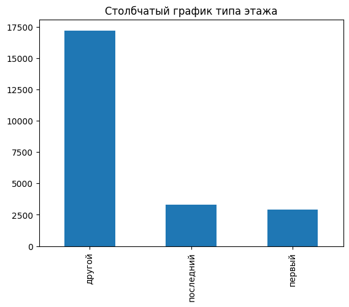

```python
#        - тип этажа квартиры («первый», «последний», «другой»); 'floor_type'

nan = data['floor_type'].isna().sum() / len(data['floor_type'])
display(f'Процент пропусков от общего числа данных {nan:.0%} в столбце', 'floor_type')
display('Принимаются следующие значения в количестве:')
display(data['floor_type'].value_counts())
display('Статистика: количество значение, количество уникальных значений, самое часто встречаемое значение, как часто оно встречается')
display (data['floor_type'].describe())
data['floor_type'].value_counts().plot(kind='bar', title='Столбчатый график типа этажа')
plt.show()
```

А остальные более автоматизировано...

```
'Процент пропусков от общего числа данных 0% в столбце'
```

```
'total_area'
```

```
'В столбце'
```

```
'total_area'
```

```
'принимаются следующие значения в количестве:'
```

```
45.00     416
42.00     380
31.00     346
60.00     345
44.00     342
         ...
147.30      1
63.68       1
30.11       1
280.30      1
55.06       1
Name: total_area, Length: 2160, dtype: int64
```

```
'Для столбца'
```

```
'total_area'
```

```
'статистика: количество значение, среднее арифметическое, стандартное отклонение, минимальное значение, первая кварталь, медиана, третья кварталь, максимальное значение.'
```

```
count    23494.000000
mean        60.158940
std         35.275246
min         12.000000
25%         40.000000
50%         52.000000
75%         69.500000
max        900.000000
Name: total_area, dtype: float64
```

```
'График распределения значений с усами'
```

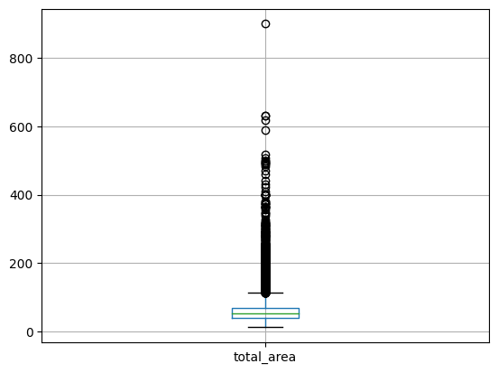

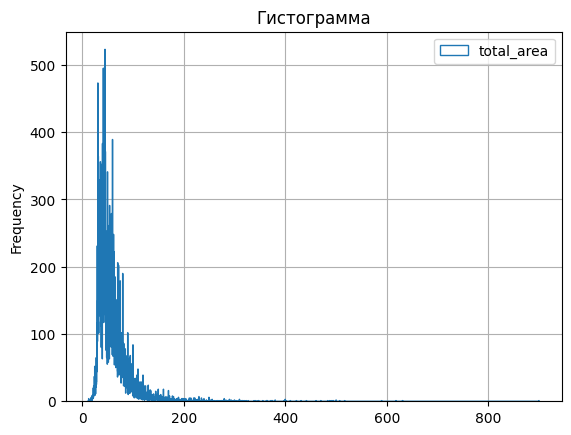

```
'Процент пропусков от общего числа данных 0% в столбце'
```

```
'living_area'
```

```
'В столбце'
```

```
'living_area'
```

```
'принимаются следующие значения в количестве:'
```

```
18.000000    879
17.000000    674
30.000000    594
16.000000    484
20.000000    476
            ...
18.860000      1
15.460000      1
47.188679      1
19.520000      1
14.250000      1
Name: living_area, Length: 2597, dtype: int64
```

```
'Для столбца'
```

```
'living_area'
```

```
'статистика: количество значение, среднее арифметическое, стандартное отклонение, минимальное значение, первая кварталь, медиана, третья кварталь, максимальное значение.'
```

```
count    23494.000000
mean        34.604475
std         22.758479
min          6.000000
25%         18.700000
50%         30.000000
75%         42.200000
max        427.546729
Name: living_area, dtype: float64
```

```
'График распределения значений с усами'
```

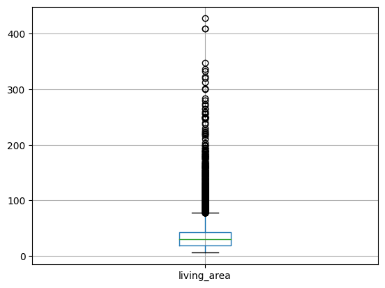

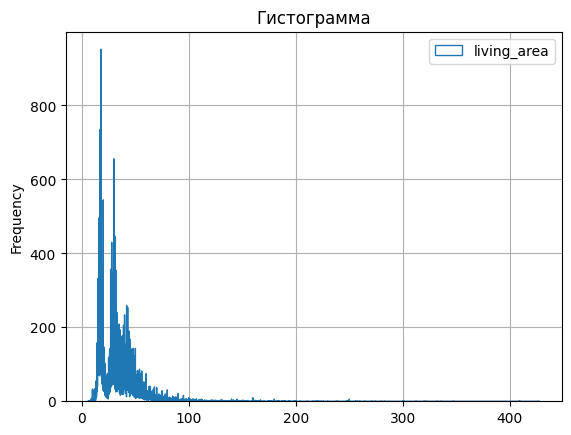

```
'Процент пропусков от общего числа данных 0% в столбце'
```

```
'kitchen_area'
```

```
'В столбце'
```

```
'kitchen_area'
```

```
'принимаются следующие значения в количестве:'
```

```
6.00     1306
10.00    1258
8.00     1106
9.00     1098
7.00     1067
         ...
15.18       1
41.30       1
16.46       1
27.57       1
16.74       1
Name: kitchen_area, Length: 1941, dtype: int64
```

```
'Для столбца'
```

```
'kitchen_area'
```

```
'статистика: количество значение, среднее арифметическое, стандартное отклонение, минимальное значение, первая кварталь, медиана, третья кварталь, максимальное значение.'
```

```
count    23494.000000
mean        10.266225
std          5.874477
min          0.000000
25%          7.000000
50%          9.000000
75%         11.600000
max        112.000000
Name: kitchen_area, dtype: float64
```

```
'График распределения значений с усами'
```

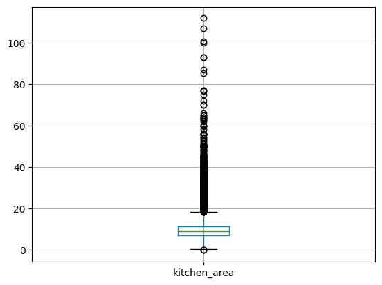

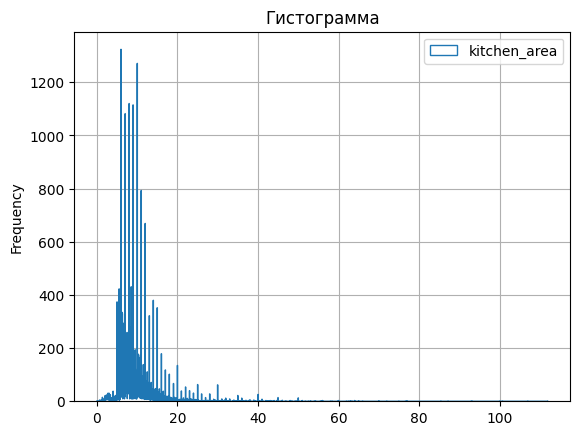

```
'Процент пропусков от общего числа данных 0% в столбце'
```

```
'last_price'
```

```
'В столбце'
```

```
'last_price'
```

```
'принимаются следующие значения в количестве:'
```

```
4500000     341
3500000     287
4000000     258
4200000     258
3600000     257
           ...
5748000       1
5535000       1
26391824      1
8353000       1
11615600      1
Name: last_price, Length: 2938, dtype: int64
```

```
'Для столбца'
```

```
'last_price'
```

```
'статистика: количество значение, среднее арифметическое, стандартное отклонение, минимальное значение, первая кварталь, медиана, третья кварталь, максимальное значение.'
```

```
count    2.349400e+04
mean     6.519802e+06
std      1.089286e+07
min      1.219000e+04
25%      3.400000e+06
50%      4.628270e+06
75%      6.750000e+06
max      7.630000e+08
Name: last_price, dtype: float64
```

```
'График распределения значений с усами'
```

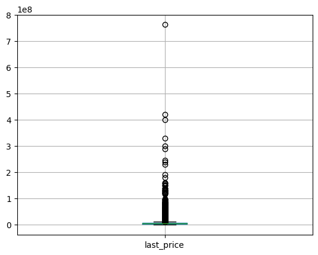

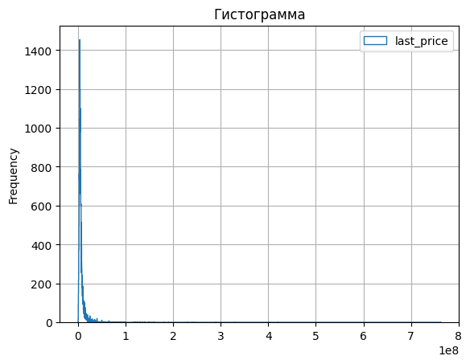

```
'Процент пропусков от общего числа данных 0% в столбце'
```

```
'rooms'
```

```
'В столбце'
```

```
'rooms'
```

```
'принимаются следующие значения в количестве:'
```

```
1     8035
2     7871
3     5760
4     1166
5      321
0      147
6      105
7       57
8       12
9        8
10       3
11       2
12       2
14       2
19       1
16       1
15       1
Name: rooms, dtype: int64
```

```
'Для столбца'
```

```
'rooms'
```

```
'статистика: количество значение, среднее арифметическое, стандартное отклонение, минимальное значение, первая кварталь, медиана, третья кварталь, максимальное значение.'
```

```
count    23494.000000
mean         2.071891
std          1.076790
min          0.000000
25%          1.000000
50%          2.000000
75%          3.000000
max         19.000000
Name: rooms, dtype: float64
```

```
'График распределения значений с усами'
```

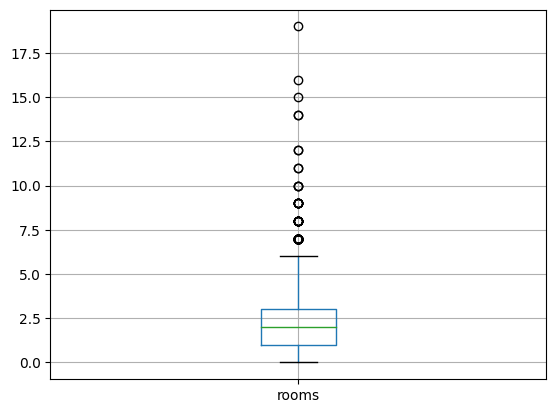

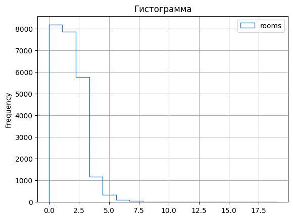

```
'Процент пропусков от общего числа данных 0% в столбце'
```

```
'ceiling_height'
```

```
'В столбце'
```

```
'ceiling_height'
```

```
'принимаются следующие значения в количестве:'
```

```
2.65    9771
2.50    3512
2.60    1641
2.70    1572
3.00    1090
        ...
4.90       1
3.58       1
2.49       1
2.89       1
4.65       1
Name: ceiling_height, Length: 168, dtype: int64
```

```
'Для столбца'
```

```
'ceiling_height'
```

```
'статистика: количество значение, среднее арифметическое, стандартное отклонение, минимальное значение, первая кварталь, медиана, третья кварталь, максимальное значение.'
```

```
count    23494.000000
mean         2.696437
std          0.220862
min          2.000000
25%          2.600000
50%          2.650000
75%          2.700000
max          6.000000
Name: ceiling_height, dtype: float64
```

```
'График распределения значений с усами'
```

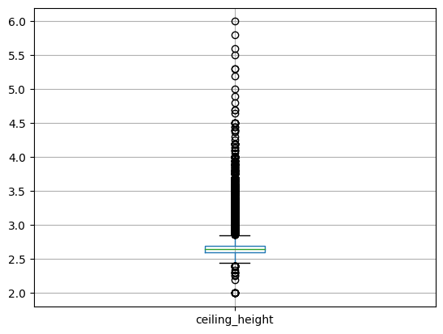

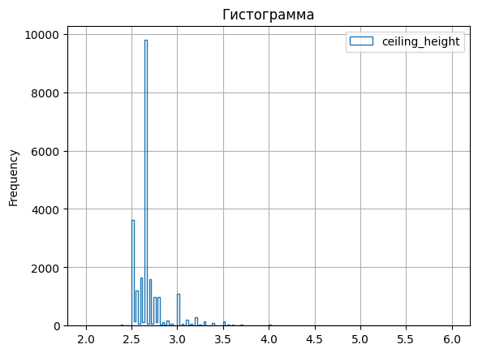

```
'Процент пропусков от общего числа данных 0% в столбце'
```

```
'floor'
```

```
'В столбце'
```

```
'floor'
```

```
'принимаются следующие значения в количестве:'
```

```
2     3333
3     3040
1     2894
4     2786
5     2603
6     1297
7     1208
8     1075
9     1047
10     684
12     521
11     519
13     374
15     340
14     332
```

[output cut: 19 more lines]

```
'Для столбца'
```

```
'floor'
```

```
'статистика: количество значение, среднее арифметическое, стандартное отклонение, минимальное значение, первая кварталь, медиана, третья кварталь, максимальное значение.'
```

```
count    23494.000000
mean         5.887120
std          4.876077
min          1.000000
25%          2.000000
50%          4.000000
75%          8.000000
max         33.000000
Name: floor, dtype: float64
```

```
'График распределения значений с усами'
```

[16 more figures not shown]

```python
#        - общая площадь;
#        - жилая площадь;
#        - площадь кухни;
#        - цена объекта;
#        - количество комнат;
#        - высота потолков;
#        - этаж квартиры;

#        - общее количество этажей в доме;
#        - расстояние до центра города в метрах;
#        - расстояние до ближайшего аэропорта;
#        - расстояние до ближайшего парка;
#        - день и месяц публикации объявления
#        - количество дней до сделки с публикации объявления

columns = ['total_area', 'living_area', 'kitchen_area', 'last_price', 'rooms', 'ceiling_height', 'floor',
           'floors_total', 'city_centers_nearest', 'airports_nearest', 'parks_nearest', 'weekday_exposition',
           'month_exposition', 'days_exposition']

for column in columns:
    nan = data[column].isna().sum() / len(data)
    display(f'Процент пропусков от общего числа данных {nan:.0%} в столбце', column)
    display('В столбце', column, 'принимаются следующие значения в количестве:')
    display(data[column].value_counts())
    display("Для столбца", column, 'статистика: количество значение, среднее арифметическое, стандартное отклонение, минимальное значение, первая кварталь, медиана, третья кварталь, максимальное значение.')
    display (data[column].describe())
    display('График распределения значений с усами')
    data.boxplot(column=column)
    plt.show()
    # data.hist(column='total_area', bins=100)
    # plt.show()
    min_column = data[column].min()
    max_column = data[column].max()
    bins_column = len(data[column].unique())
    data.plot( kind='hist',
             y=column,
             histtype='step',
             #range=(min_column, max_column),
             bins=bins_column,
             title='Гистограмма',
             grid=True)
    plt.show()
```

**Вывод**: Предствленные параметры имеют хорошее качество и пригодны для анализа. Так как большая часть данных относятся к Санкт-Петербургу, то для этого города анализ может выявить больше закономерностей и взаимосвязей.

#### Задание: Изучите, как быстро продавались квартиры

Как видно из данных выше (последний столбец). У нас 13% пропусков в столбце `days_exposition` значит 13% квартир не были проданы на момент сбора данных.

Среднее значение 181 день, а медиана 95 дней. При этом были сделки за 1 день! Но и есть **объект**, который **продавался 1580 дней - это более четырех лет**!

Мы можем считать нормальным сроком продажи 3 месяца (медиана). А быстрой продажой считать ту, которая произошла за 45 дней(первая кварталь) или раньше.

### Задание: Какие факторы больше всего влияют на общую (полную) стоимость объекта?

```python
data.corr()
```

|  | total_images | last_price | total_area | rooms | ceiling_height | floors_total | living_area | floor | is_apartment | studio | ... | parks_around3000 | parks_nearest | ponds_around3000 | ponds_nearest | days_exposition | sq_m_price | weekday_exposition | month_exposition | year_exposition | city_centers_nearest_km |
| --- | --- | --- | --- | --- | --- | --- | --- | --- | --- | --- | --- | --- | --- | --- | --- | --- | --- | --- | --- | --- | --- |
| total_images | 1.000000 | 0.104234 | 0.115869 | 0.097974 | 0.054274 | 0.011210 | 0.101704 | 0.032502 | 0.010892 | -0.028892 | ... | 0.019466 | -0.009704 | -0.011507 | -0.003744 | -0.026800 | 0.133505 | -0.010308 | 0.005636 | 0.140328 | -0.047843 |
| last_price | 0.104234 | 1.000000 | 0.654919 | 0.364751 | 0.293636 | -0.006833 | 0.586971 | 0.025688 | 0.023648 | -0.025072 | ... | 0.148546 | -0.017751 | 0.159460 | -0.083859 | 0.081228 | 0.738480 | 0.001972 | 0.001739 | -0.041989 | -0.205091 |
| total_area | 0.115869 | 0.654919 | 1.000000 | 0.764551 | 0.398223 | -0.074631 | 0.953839 | -0.025182 | 0.030936 | -0.072667 | ... | 0.163952 | -0.023276 | 0.165604 | -0.097060 | 0.150871 | 0.307321 | -0.003718 | 0.003135 | -0.077649 | -0.232021 |
| rooms | 0.097974 | 0.364751 | 0.764551 | 1.000000 | 0.248431 | -0.226519 | 0.832538 | -0.149780 | 0.001356 | -0.152682 | ... | 0.136462 | -0.053783 | 0.094757 | -0.058007 | 0.125514 | 0.057328 | -0.003494 | -0.003243 | -0.054163 | -0.183691 |
| ceiling_height | 0.054274 | 0.293636 | 0.398223 | 0.248431 | 1.000000 | -0.083792 | 0.376381 | -0.045775 | 0.064794 | 0.011619 | ... | 0.225447 | -0.059696 | 0.188870 | -0.110118 | 0.111418 | 0.293739 | -0.021797 | -0.002210 | -0.051678 | -0.294758 |
| floors_total | 0.011210 | -0.006833 | -0.074631 | -0.226519 | -0.083792 | 1.000000 | -0.159186 | 0.677815 | -0.025543 | 0.068768 | ... | -0.251745 | 0.099245 | -0.122235 | 0.040726 | -0.053853 | 0.148965 | 0.011447 | 0.017273 | 0.009025 | 0.020085 |
| living_area | 0.101704 | 0.586971 | 0.953839 | 0.832538 | 0.376381 | -0.159186 | 1.000000 | -0.089445 | 0.029524 | -0.053931 | ... | 0.175641 | -0.049852 | 0.150024 | -0.085435 | 0.143026 | 0.233350 | -0.003493 | -0.000730 | -0.070312 | -0.227740 |
| floor | 0.032502 | 0.025688 | -0.025182 | -0.149780 | -0.045775 | 0.677815 | -0.089445 | 1.000000 | -0.013065 | 0.035491 | ... | -0.162668 | 0.075286 | -0.075056 | 0.026159 | -0.039965 | 0.128604 | 0.010464 | 0.020383 | 0.006171 | 0.010052 |
| is_apartment | 0.010892 | 0.023648 | 0.030936 | 0.001356 | 0.064794 | -0.025543 | 0.029524 | -0.013065 | 1.000000 | -0.003590 | ... | 0.018882 | -0.030778 | 0.019207 | 0.006564 | 0.016387 | 0.029744 | -0.009681 | 0.001034 | 0.008356 | 0.006484 |
| studio | -0.028892 | -0.025072 | -0.072667 | -0.152682 | 0.011619 | 0.068768 | -0.053931 | 0.035491 | -0.003590 | 1.000000 | ... | -0.030698 | 0.006936 | 0.000811 | 0.001840 | -0.022073 | 0.015731 | -0.000852 | 0.001592 | 0.011172 | -0.006914 |
| open_plan | -0.024580 | -0.008729 | -0.035126 | -0.036187 | -0.001595 | 0.051096 | -0.022281 | 0.036106 | -0.002420 | -0.004243 | ... | -0.010010 | 0.010712 | 0.008541 | -0.003403 | -0.024181 | 0.008413 | 0.011064 | 0.025885 | -0.021447 | -0.004254 |
| kitchen_area | 0.116566 | 0.494158 | 0.643706 | 0.309180 | 0.331239 | 0.130351 | 0.475108 | 0.112901 | 0.034132 | -0.099418 | ... | 0.092441 | 0.020809 | 0.145571 | -0.095709 | 0.117151 | 0.376373 | -0.006809 | 0.003397 | -0.058693 | -0.187432 |
| balcony | 0.048553 | 0.008882 | 0.011581 | -0.013494 | -0.043244 | 0.173807 | -0.011017 | 0.169611 | 0.029117 | 0.028761 | ... | -0.078008 | 0.032000 | -0.039250 | 0.021948 | -0.028204 | 0.021476 | -0.001026 | 0.009900 | 0.004157 | 0.064950 |
| airports_nearest | -0.003356 | -0.026350 | -0.030387 | -0.060999 | -0.080726 | 0.110581 | -0.051519 | 0.073076 | 0.016204 | -0.021722 | ... | 0.001505 | -0.071089 | -0.050106 | 0.014019 | -0.018860 | -0.039692 | 0.001989 | 0.006483 | 0.007780 | 0.272035 |
| city_centers_nearest | -0.047843 | -0.205091 | -0.232021 | -0.183691 | -0.294758 | 0.020085 | -0.227740 | 0.010052 | 0.006484 | -0.006914 | ... | -0.160606 | -0.040023 | -0.073727 | 0.030033 | -0.059914 | -0.316878 | 0.009422 | -0.008771 | 0.029874 | 1.000000 |
| parks_around3000 | 0.019466 | 0.148546 | 0.163952 | 0.136462 | 0.225447 | -0.251745 | 0.175641 | -0.162668 | 0.018882 | -0.030698 | ... | 1.000000 | -0.258694 | 0.302823 | -0.168570 | 0.060888 | 0.181729 | -0.010720 | -0.004956 | -0.041256 | -0.160606 |
| parks_nearest | -0.009704 | -0.017751 | -0.023276 | -0.053783 | -0.059696 | 0.099245 | -0.049852 | 0.075286 | -0.030778 | 0.006936 | ... | -0.258694 | 1.000000 | 0.076502 | 0.003879 | 0.023682 | 0.004439 | -0.002193 | 0.019184 | -0.022011 | -0.040023 |
| ponds_around3000 | -0.011507 | 0.159460 | 0.165604 | 0.094757 | 0.188870 | -0.122235 | 0.150024 | -0.075056 | 0.019207 | 0.000811 | ... | 0.302823 | 0.076502 | 1.000000 | -0.340861 | 0.073764 | 0.188948 | 0.002494 | -0.009338 | -0.036084 | -0.073727 |
| ponds_nearest | -0.003744 | -0.083859 | -0.097060 | -0.058007 | -0.110118 | 0.040726 | -0.085435 | 0.026159 | 0.006564 | 0.001840 | ... | -0.168570 | 0.003879 | -0.340861 | 1.000000 | -0.078690 | -0.103641 | -0.003235 | 0.013806 | 0.036590 | 0.030033 |
| days_exposition | -0.026800 | 0.081228 | 0.150871 | 0.125514 | 0.111418 | -0.053853 | 0.143026 | -0.039965 | 0.016387 | -0.022073 | ... | 0.060888 | 0.023682 | 0.073764 | -0.078690 | 1.000000 | 0.048650 | -0.024299 | -0.030869 | -0.611700 | -0.059914 |
| sq_m_price | 0.133505 | 0.738480 | 0.307321 | 0.057328 | 0.293739 | 0.148965 | 0.233350 | 0.128604 | 0.029744 | 0.015731 | ... | 0.181729 | 0.004439 | 0.188948 | -0.103641 | 0.048650 | 1.000000 | -0.006995 | -0.003210 | 0.008812 | -0.316878 |
| weekday_exposition | -0.010308 | 0.001972 | -0.003718 | -0.003494 | -0.021797 | 0.011447 | -0.003493 | 0.010464 | -0.009681 | -0.000852 | ... | -0.010720 | -0.002193 | 0.002494 | -0.003235 | -0.024299 | -0.006995 | 1.000000 | 0.011203 | -0.004285 | 0.009422 |
| month_exposition | 0.005636 | 0.001739 | 0.003135 | -0.003243 | -0.002210 | 0.017273 | -0.000730 | 0.020383 | 0.001034 | 0.001592 | ... | -0.004956 | 0.019184 | -0.009338 | 0.013806 | -0.030869 | -0.003210 | 0.011203 | 1.000000 | -0.270549 | -0.008771 |
| year_exposition | 0.140328 | -0.041989 | -0.077649 | -0.054163 | -0.051678 | 0.009025 | -0.070312 | 0.006171 | 0.008356 | 0.011172 | ... | -0.041256 | -0.022011 | -0.036084 | 0.036590 | -0.611700 | 0.008812 | -0.004285 | -0.270549 | 1.000000 | 0.029874 |
| city_centers_nearest_km | -0.047843 | -0.205091 | -0.232021 | -0.183691 | -0.294758 | 0.020085 | -0.227740 | 0.010052 | 0.006484 | -0.006914 | ... | -0.160606 | -0.040023 | -0.073727 | 0.030033 | -0.059914 | -0.316878 | 0.009422 | -0.008771 | 0.029874 | 1.000000 |

25 rows × 25 columns

Так же мы расмотрим влияние следующих параметров:

- количество комнат;
- типа этажа, на котором расположена квартира (первый, последний, другой);
- даты размещения (день недели, месяц, год).

Мы будем произвоить исследования на уже совершенных сделках (`days_exposition` >0), так как без согласия покупателя, продавец может писать любые объявления.

#### Последняя цена и общая площадь

```
0.6549185023861153
```

| total_area | last_price |
| --- | --- |
| 12.0 | 2400000.0 |
| 13.0 | 2350000.0 |
| 13.2 | 1686000.0 |
| 14.0 | 1190000.0 |
| 15.0 | 1725000.0 |
| ... | ... |
| 590.0 | 65000000.0 |
| 618.0 | 300000000.0 |
| 631.0 | 140000000.0 |
| 631.2 | 140000000.0 |
| 900.0 | 420000000.0 |

2160 rows × 1 columns

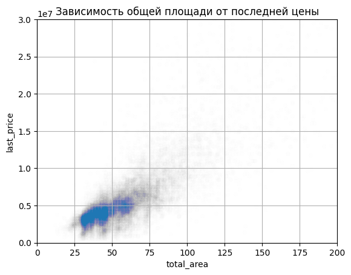

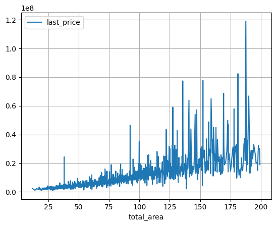

```python
display (data['last_price'].corr(data['total_area']))
display(data.pivot_table(index='total_area', values='last_price'))
data.query('days_exposition >0').plot(x='total_area', y='last_price', kind='scatter', alpha=0.005, xlim=(0, 200), ylim=(0, 30000000), grid=True,
         title='Зависимость общей площади от последней цены')
plt.show()
# data.plot(x='total_area', y='last_price', kind='hexbin', sharex=False, gridsize=50)
(data
     .query('total_area <200 and days_exposition >0')
     .pivot_table(index='total_area', values='last_price', aggfunc='median')
     .plot(grid=True)
)
plt.show()
```

**Вывод**: как мы водим с увеличением общей площади растет последняя цена. При этом после 100 квадратных метров диапозон цен значительно увеличивается.

#### Последняя цена и жилая площадь

```
0.5869705975211489
```

| living_area | last_price |
| --- | --- |
| 6.000000 | 3799000.0 |
| 6.258206 | 1625000.0 |
| 6.354486 | 1686000.0 |
| 6.500000 | 4050000.0 |
| 7.221007 | 1725000.0 |
| ... | ... |
| 336.136734 | 230000000.0 |
| 347.500000 | 91500000.0 |
| 409.000000 | 65000000.0 |
| 409.700000 | 420000000.0 |
| 427.546729 | 140000000.0 |

2597 rows × 1 columns

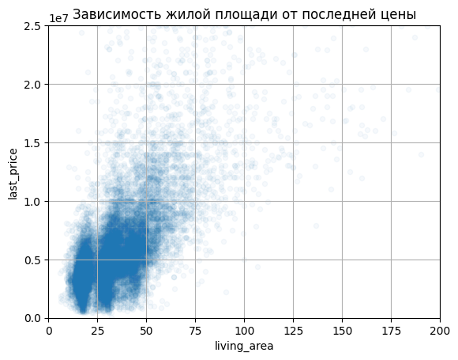

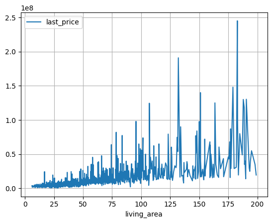

```python
display (data['last_price'].corr(data['living_area']))
display(data.pivot_table(index='living_area', values='last_price'))
data.query('days_exposition >0').plot(x='living_area', y='last_price', kind='scatter', alpha=0.04, xlim=(0, 200), ylim=(0, 25000000), grid=True,
         title='Зависимость жилой площади от последней цены')
plt.show()


(data
     .query('living_area <200 and days_exposition >0')
     .pivot_table(index='living_area', values='last_price', aggfunc='median')
     .plot(grid=True)
)
plt.show()
```

**Вывод**: Из графиков видно, что последняя цена растет с ростом жилой площади. Диапозон цены значительно увеличивается после 75 квадратных метров. Так же на графике выше видно, что 3 крупных скопления значений. Вероятно, это площади комнат, по которым считается жилая площадь.

#### Последняя цена и площадь кухни

```
0.4941583717225934
```

| kitchen_area | last_price |
| --- | --- |
| 0.000000 | 3025000.0 |
| 0.090000 | 2950000.0 |
| 0.566667 | 13351000.0 |
| 0.600000 | 2550000.0 |
| 0.630000 | 1737000.0 |
| ... | ... |
| 93.200000 | 82400000.0 |
| 100.000000 | 65000000.0 |
| 100.700000 | 12500000.0 |
| 107.000000 | 85000000.0 |
| 112.000000 | 420000000.0 |

1941 rows × 1 columns

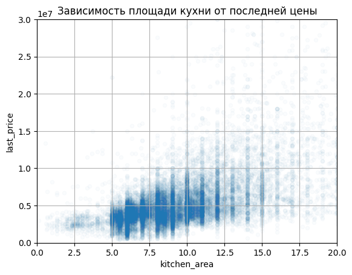

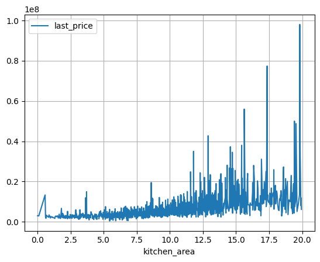

```python
display (data['last_price'].corr(data['kitchen_area']))
display(data.pivot_table(index='kitchen_area', values='last_price'))
data.query('days_exposition >0').plot(x='kitchen_area', y='last_price', kind='scatter', alpha=0.02, xlim=(0, 20), ylim=(0, 30000000), grid=True,
         title='Зависимость площади кухни от последней цены')
plt.show()


(data
     .query('kitchen_area <20 and days_exposition >0')
     .pivot_table(index='kitchen_area', values='last_price', aggfunc='median')
     .plot(grid=True)
)
plt.show()
```

**Вывод**: Общая тенденция чем больше площадь кухни, тем больше последняя цена. Для наиболее распотранненных объектах, при ограничении площади кухни в 20 квадртаных метров, мы можем увидеть, несколько пиков, которые связыны с массовым панельным строительством. А пиковые влияния на цену оказывать кухни от 7 до 17 квадратных метров. Можно предположить, что кухни от 9 до 13 считаются оптимальными, а мечта- это кухня 17 квадртных метров.

#### Последняя цена и цена за 1 квадратный метр

| sq_m_price | median last_price |
| --- | --- |
| 112 | 12190.0 |
| 7963 | 430000.0 |
| 9616 | 500000.0 |
| 10186 | 550000.0 |
| 10369 | 450000.0 |
| ... | ... |
| 995984 | 124000000.0 |
| 1000749 | 401300000.0 |
| 1542605 | 289238400.0 |
| 1736843 | 330000000.0 |
| 1907500 | 763000000.0 |

14191 rows × 1 columns

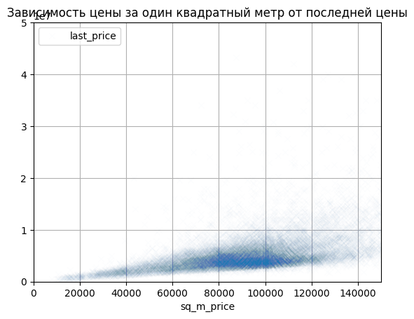

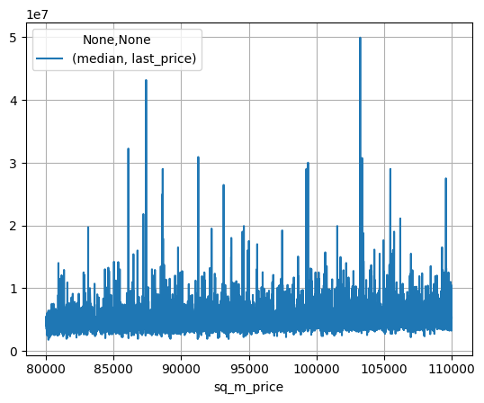

```python
# display (data['sq_m_price'].corr(data['last_price']))
display(data.pivot_table(index='sq_m_price', values='last_price', aggfunc=['median']))
data.query('days_exposition >0 ').plot(x='sq_m_price', y='last_price',style='x', alpha=0.01, grid=True, xlim=(0, 150000), ylim=(0, 50000000),
          title='Зависимость цены за один квадратный метр от последней цены')
plt.show()




(data.query('80000 < sq_m_price <110000 and days_exposition >0 ')
.pivot_table(index='sq_m_price', values='last_price', aggfunc=['median'])
.plot(grid=True)
)
plt.show()
```

**Вывод**: Общая тенденция такова, что с ростом цены за 1 квадратный метр увеличивается последняя цена. Так же мы обнаружили зону от 80000 до 100000 рублей, где большое скопление значений. Скорее всего покупатели считали эту цену за один квадратный метр разумной. И в этой зоне последняя цена имеет ярко выраженый диапозон.

**Гипотиза**: В зоне 80-100 тысячи рублей за квадратный метр и последней цены от 4 до 12 миллионов происходит наибольшее количество сделок. И это связано с покупательской способностью.